# 02rl · FunnyBird CBM: matched visibility-aware relabeling test

**Report question.** Did positive concept labels attached to invisible parts cause some of the controlled backwash established for the standard FunnyBird CBM in notebook 02?

**Population.** Accepted converged Standard CBM versus matched converged CBM-RLv2, seed 1. Both are ResNet-50 Koh-architecture Joint CBMs. This notebook contains no MCBM and no gamma sweep. `RLv2` means visibility-aware relabeling, not reinforcement learning.

**Causal scope.** Training/validation images, class labels, architecture, optimizer, schedule, seed, epoch, and fixed-render evaluation must match. The only permitted training-record difference is `attribute_label`. If any parity check fails, later differences are diagnostics rather than causal evidence.

## What this notebook must prove

Notebook 02 already proved the standard-CBM event. This notebook does not ask whether backwash exists again. It tests one proposed cause.

| Step | Needed fact | Why it is needed |
| --- | --- | --- |
| 1 | reproduce the accepted standard-CBM motivation | prevents RLv2 from replacing the discovery story |
| 2 | define and count the label changes | identifies the manipulated training signal |
| 3 | prove record, configuration, checkpoint, and render parity | makes the comparison causal with respect to labels |
| 4 | verify both models are usable | excludes collapse or failed training |
| 5 | compare the controlled event on identical swaps | primary causal result |
| 6 | count resolved, remaining, and introduced events | distinguishes improvement from merely moving averages |
| 7 | decompose original donor/source scores, donor rise, source release, total response, and final margin | identifies where the numerical change occurs without calling the starting margin pure context |
| 8 | repeat direction, visibility, exact-value, species, and downstream checks | tests alternative explanations and the remainder |
| 9 | align the standard and RLv2 summaries | states exactly what changed and what did not |

Every result follows: **question → variables/prediction → method → figure → literal observation → alternative → discriminating test → limited conclusion → next question**. No result is accepted until its figure is shown in chat.

Part names are outcomes, not mechanisms. Tail has the largest manipulated label burden in this dataset and therefore carries the strongest preregistered prediction, but every component is measured for all five parts. Because RLv2 retrains one shared encoder, changes outside tail are possible and informative.

## Standard-figure replication checklist

The rule is mechanical. If adding RLv2 requires only another bar, line, or row, the regimes share one figure. If it changes the construction, the exact Standard figure is shown first and the same calculation with the RLv2 model is shown directly below it. Input-only renderer pictures are shown once because the hash audit proves that both models saw the identical pixels.

| Standard notebook figure | RLv2 location | Display rule |
| --- | --- | --- |
| 1 model health | Figure 3 | simple paired rows/panels |
| 2 and 2b renderer operation | Figure 4 | input-only; identical pixels shown once |
| 3 response | Figure 8 | simple second distribution/rate |
| 3b score decomposition | Figures 7 and 7b | same quantities plus paired difference |
| 4 and 4b final outcome | Figures 5, 5b, and 6 | paired primary rate; exact Standard 4b then matching RLv2 5b; transitions remain additional |
| 5 direction | Figure 9 | simple second line |
| 6 visibility | Figure 10 | simple second line |
| 6b label/mask conflict | Figure 1 | intervention itself |
| 6c conflict versus response | Figure 13a | Standard image, then same RLv2 calculation |
| 7 exact-value confusion | Figure 11 | two identical heatmap rows |
| 7a tail appearance | motivation panel above Figure 1 | input-only; unchanged renders |
| 7b support versus outcomes | Figure 13b | two identical rows of three panels |
| 7c support versus absent score | Figure 13c | same axes side by side |
| 8 source-species residual | Figure 12 | simple second marker series |
| 8b basic species decoding | Figure 13 | simple paired panels |
| 8c conditional information/saved-head use | Figure 13d | exact Standard output, then exact RLv2 output |
| 8d off-target frozen-head erasure | Figure 13e | exact Standard output, then exact RLv2 output |
| 9 contributor-family omission | Figure 14 | exact Standard output, then exact RLv2 output |
| 9b synthesis | Figure 16 | simple second bar |
| 10 donor-species probability | Figure 15 | simple second bar |

## The two CBMs and the notation

Both models implement the same computation:

```
x_i → ResNet-50 encoder → 26 raw concept logits z_i
                              ↓
                    one linear layer Wz_i+b
                              ↓
                       50 species logits
```

Both use Koh Joint's normalized `L_task + 0.01 × L_concept`. The class head reads the 26 raw concept logits, not hard 0/1 decisions and not a separate MCBM latent vector. Grounding analyses use raw `z`, not probability `p`.

Neither model has an MCBM gamma penalty or a `±3` representation target. Their raw logits are unbounded. Notebook 03's soft targets belong only to MCBM.

| Symbol | Meaning |
| --- | --- |
| `c_standard[i,j]` | original processed 0/1 concept label |
| `v[i,g(j)]` | whether the renderer says the mapped part is visible |
| `c_RLv2[i,j] = c_standard[i,j] × v[i,g(j)]` | visibility-aware concept label |
| `S_orig`, `D_orig` | source and donor concept logits on the original image |
| `S_cf`, `D_cf` | source and donor concept logits after replacement |
| `m_orig = D_orig-S_orig` | donor-minus-source margin before replacement |
| `m_cf = D_cf-S_cf` | final donor-minus-source margin |
| `response_delta = m_cf-m_orig` | donorward movement caused by replacement |

The controlled candidate event remains exactly the notebook-02 definition:

`response_delta > 0 and m_cf < 0`.

RLv2 is predicted to lower `S_cf` most directly. It may raise `D_cf`, but fewer positive training labels make that less certain. Because RLv2 can also change `m_orig`, stronger `response_delta` is secondary; the primary endpoint is the final event on the identical replacement.

## 0 · Accepted standard-CBM evidence that motivated RLv2

The seven images below are copied verbatim from the executed notebook 02. They are not recomputed with the RLv2 model and are not new results.

### Notebook-02 Figure 2 · The validated one-part renderer operation

This is the exact Standard input audit. RLv2 uses the same accepted render hashes, so recomputing it would produce no model-dependent result.

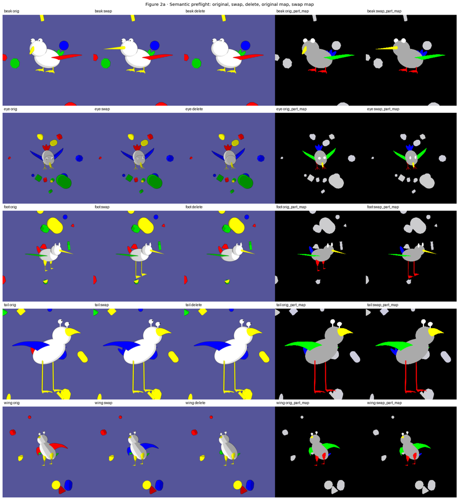

### Notebook-02 Figure 2b · Saved examples for every replaced part

These saved original/replacement examples are shared inputs. The later parity table proves that Standard and RLv2 are evaluated on these identical pixels.

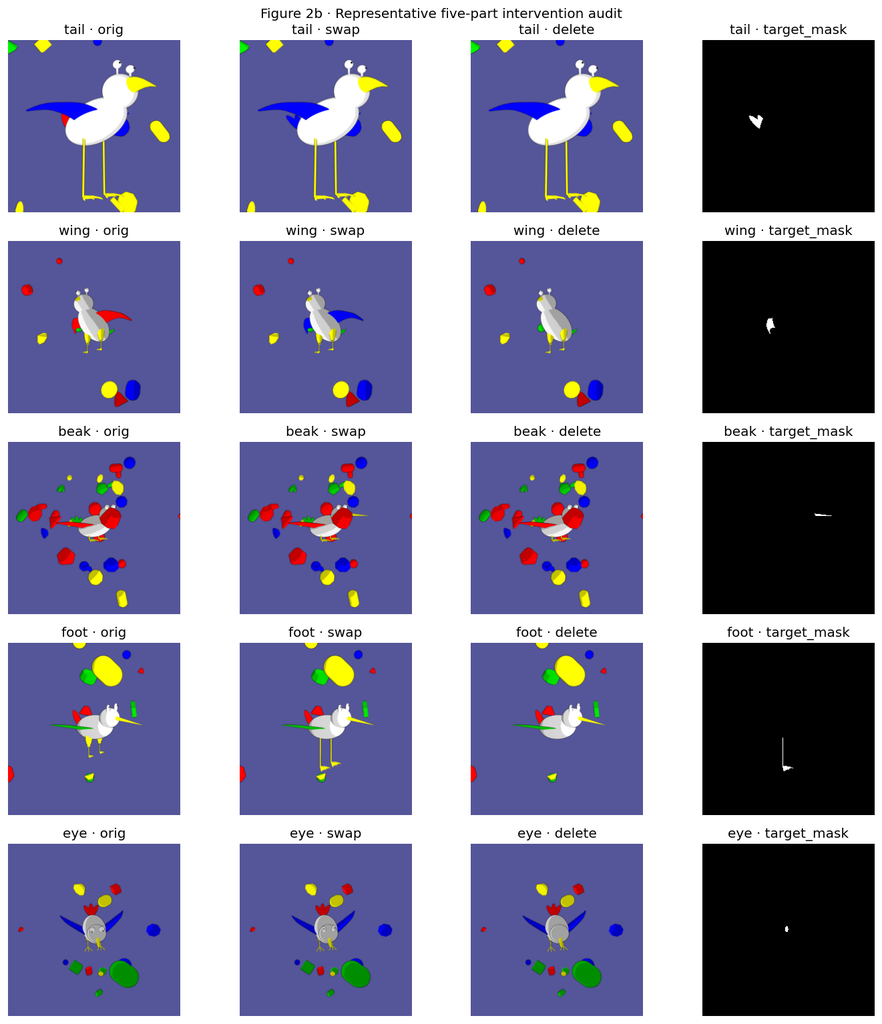

### Notebook-02 Figure 4 · Controlled standard-CBM backwash predicate

The standard model usually moves toward the inserted donor, but the old source often remains higher. Tail, beak, and eye contain the largest controlled candidate fractions.

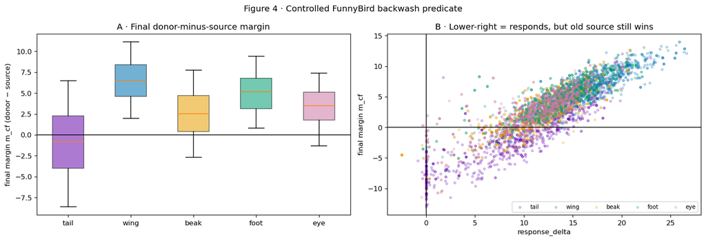

### Notebook-02 Figure 6 · Visibility contributes but is insufficient

Larger inserted masks generally improve the final margin. Clear visibility does not reduce every part's candidate rate to zero, so visibility alone is not a complete explanation.

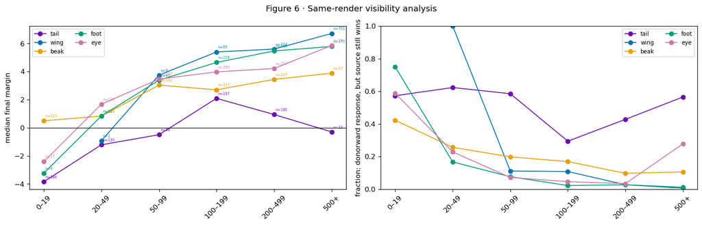

### Notebook-02 Figure 6b · Positive labels can conflict with visible evidence

The original training data contain positive concept labels whose named part is not visible. This is a measured property of the targets, not yet a causal model effect.

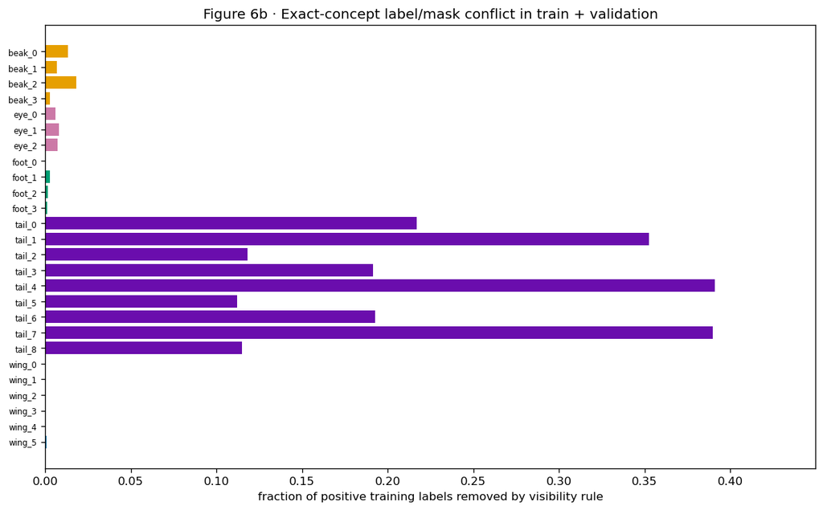

### Notebook-02 Figure 9b · Outcome and proposed contributors in one part order

Tail is high in the controlled outcome, clear-visibility remainder, label conflict, and donor-value error. The four fractions have different denominators and must not be added.

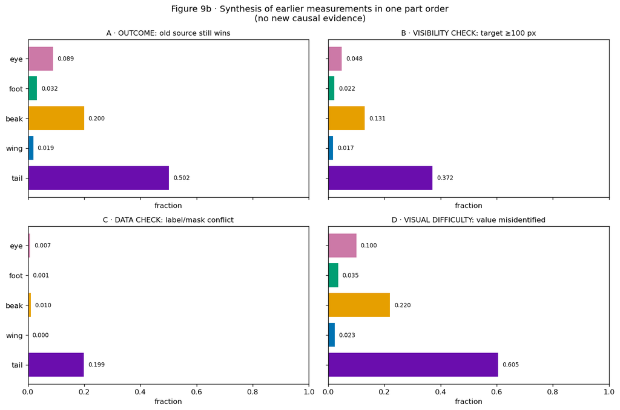

### Notebook-02 Figure 7a · The unchanged nine-value tail input inventory

These are input-only renderer crops. RLv2 changes training labels and models, not the tail pixels or value identities, so a second copy would be identical rather than a new RLv2 result.

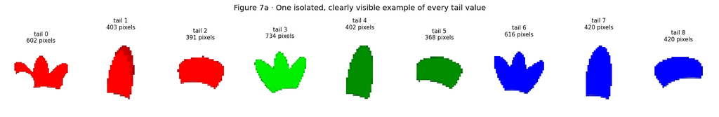

## Predictions fixed before reading RLv2 behavior

1. Tail should show the largest reduction in candidate events because it has the largest training-label conflict.
2. Beak and eye may improve modestly.
3. Foot and wing should change little.
4. The most direct mechanism is a lower removed-source score `S_cf`.
5. The final margin `m_cf=D_cf-S_cf` should move right.
6. `response_delta` may not rise by the same amount because RLv2 intentionally changes low-visibility original images too.
7. Exact-value and source-species residuals may remain; RLv2 manipulates labels, not the number of variants or the unchanged source body.

```python
# ALT: Load only the matched standard-CBM and CBM-RLv2 fixed-render rows and fail if any render identity differs.
import os, re, json, sys, hashlib, subprocess, pickle
from pathlib import Path
import numpy as np
import pandas as pd
import matplotlib.pyplot as plt
from PIL import Image
from IPython.display import display, Markdown

CURATED = Path(os.environ["CURATED_DATA"])
CWD = Path.cwd()
REPO = CWD if (CWD/"analysis").is_dir() else CWD.parent
MATCHED_FOLLOWUP_ROOT = Path(os.environ["FUNNYBIRD_MATCHED_FOLLOWUP_ROOT"])
for regime in ["standard", "rlv2"]:
    manifest = MATCHED_FOLLOWUP_ROOT/regime/"SUCCESS.json"
    if not manifest.is_file(): raise FileNotFoundError(manifest)
ORDER = ["tail", "wing", "beak", "foot", "eye"]
COLORS = {"tail":"#6A0DAD", "wing":"#0072B2", "beak":"#E69F00",
          "foot":"#009E73", "eye":"#CC79A7"}
REGIME_COLORS = {"standard":"#0072B2", "RLv2":"#009E73"}
plt.rcParams.update({"figure.dpi":120, "axes.grid":False})
pd.set_option("display.max_rows",250); pd.set_option("display.max_columns",50)

SEED=1
MODEL_BASE=CURATED/"koh_joint_resnet_accelerated_converged_v1"/"funnybirds"
MODEL_ROOTS={"standard":MODEL_BASE/"standard"/"seed1",
             "RLv2":MODEL_BASE/"rlv2"/"seed1"}
SWAP_DIR=CURATED/"swap_koh_joint_resnet_accelerated_converged_v1_seed1"
VISIBILITY_DIR=CURATED/"funnybird_visibility_correction_v1"
for root in [*MODEL_ROOTS.values(),SWAP_DIR]:
    manifest=root/"SUCCESS.json"
    if not manifest.is_file(): raise FileNotFoundError(manifest)
    subprocess.run([sys.executable,str(REPO/"analysis"/"canonical_manifest.py"),
                    "verify","--manifest",str(manifest)],check=True)
subprocess.run([sys.executable,str(REPO/"analysis"/"validate_fixed_swaps.py"),
                "--out",str(SWAP_DIR)],check=True)

STD=pd.read_csv(SWAP_DIR/"funnybirds-cbm-s1.csv")
RL=pd.read_csv(SWAP_DIR/"funnybirds-cbm-rlv2matched-s1.csv")
for frame in [STD,RL]:
    if "response_delta" not in frame:
        frame["response_delta"]=frame.margin-(frame.z_new_orig-frame.z_old_orig)
    frame["m_orig"]=frame.z_new_orig-frame.z_old_orig
    frame["m_cf"]=frame.z_new-frame.z_old
    frame["donor_gain"]=frame.z_new-frame.z_new_orig
    frame["source_decrease"]=frame.z_old_orig-frame.z_old
    if not np.allclose(frame.m_cf,frame.margin):
        raise RuntimeError("stored margin disagrees with z_new-z_old")
    if not np.allclose(frame.m_cf,frame.m_orig+frame.donor_gain+frame.source_decrease):
        raise RuntimeError("starting-margin/response decomposition does not close")
    frame["candidate"]=(frame.response_delta>0)&(frame.margin<0)
visibility=pd.read_csv(VISIBILITY_DIR/"visibility.csv")
if visibility.duplicated(["render_id","part"]).any():
    raise RuntimeError("corrected visibility key is not unique")
for frame in [STD,RL]:
    original_rows=len(frame)
    merged=frame.merge(visibility[["render_id","part","legacy_single_instance_pixels",
                                   "corrected_all_instance_pixels","added_second_instance_pixels"]],
                       on=["render_id","part"],how="left",validate="many_to_one")
    if len(merged)!=original_rows or merged.corrected_all_instance_pixels.isna().any():
        raise RuntimeError("corrected visibility does not cover all paired rows")
    if not np.array_equal(merged.pixel_count_cf.astype(int),
                          merged.legacy_single_instance_pixels.astype(int)):
        raise RuntimeError("legacy visibility does not match accepted CSV")
    frame.drop(frame.index,inplace=True)
    for column in merged.columns: frame[column]=merged[column]
    frame["pixel_count_cf_legacy_single_instance"]=frame.pixel_count_cf
    frame["pixel_count_cf"]=frame.corrected_all_instance_pixels.astype(int)
keys=["render_id"]
Q=STD.merge(RL,on=keys,validate="one_to_one",suffixes=("_standard","_rl"))
same_cols=["image_cf_sha256","image_orig_sha256","part","direction","sid_src","sid_donor",
           "var_src","var_donor","li","pixel_count_cf"]
for col in same_cols:
    a,b=f"{col}_standard",f"{col}_rl"
    if not Q[a].equals(Q[b]): raise RuntimeError(f"fixed rows disagree on {col}")
    Q[col]=Q[a]
Q["candidate_standard"]=(Q.response_delta_standard>0)&(Q.margin_standard<0)
Q["candidate_rl"]=(Q.response_delta_rl>0)&(Q.margin_rl<0)
Q["pair_id"]=Q.apply(lambda r:f"{r['part']}:{min(r.sid_src,r.sid_donor)}-{max(r.sid_src,r.sid_donor)}",axis=1)
Q["transition"]=np.select([
    Q.candidate_standard&~Q.candidate_rl,
    Q.candidate_standard&Q.candidate_rl,
    ~Q.candidate_standard&Q.candidate_rl],
    ["resolved","remaining","introduced"],default="never candidate")

FB_ROOT=Path(os.environ.get("FUNNYBIRDS_ROOT",CURATED/"FunnyBirds"))
sys.path.insert(0,str(REPO/"data"/"funnybirds"))
import funnybirds_concepts as fbc
parts=fbc.load_parts(FB_ROOT); CONCEPT_NAMES=fbc.concept_names(parts); SPANS=fbc.group_slices(parts)
CONCEPT_PART={n:p for p,(lo,hi) in SPANS.items() for n in CONCEPT_NAMES[lo:hi]}
print("validated fixed-render root:",SWAP_DIR)
print("paired rows:",len(Q),"parts:",sorted(Q.part.unique()))
display(Q.groupby("part").agg(
    swaps=("render_id","size"),
    mean_legacy_pixels=("pixel_count_cf_legacy_single_instance_standard","mean"),
    mean_corrected_pixels=("pixel_count_cf","mean"),
    swaps_with_added_second_instance=("added_second_instance_pixels_standard",lambda x:int((x>0).sum()))
).reindex(ORDER).round(2))
```

```
[MANIFEST VERIFIED] /scratch/network/cr7998/cv_emergence_project/curated_data/koh_joint_resnet_accelerated_converged_v1/funnybirds/standard/seed1/SUCCESS.json
```

```
[MANIFEST VERIFIED] /scratch/network/cr7998/cv_emergence_project/curated_data/koh_joint_resnet_accelerated_converged_v1/funnybirds/rlv2/seed1/SUCCESS.json
[MANIFEST VERIFIED] /scratch/network/cr7998/cv_emergence_project/curated_data/swap_koh_joint_resnet_accelerated_converged_v1_seed1/SUCCESS.json
```

```
[checked] funnybirds-cbm-rlv2matched-s1.csv: 5000 fixed renders; unique_cf_hashes=3040; unique_orig_hashes=250; changed_from_orig=0.983
[checked] funnybirds-cbm-s1.csv: 5000 fixed renders; unique_cf_hashes=3040; unique_orig_hashes=250; changed_from_orig=0.983
FIXED SWAP VALIDATION PASSED: 2 model CSVs, 5000 counterfactual RGB IDs, 250 original RGB IDs; hashes agree across models and each CSV passed diversity/intervention checks.
```

```
validated fixed-render root: /scratch/network/cr7998/cv_emergence_project/curated_data/swap_koh_joint_resnet_accelerated_converged_v1_seed1
paired rows: 5000 parts: ['beak', 'eye', 'foot', 'tail', 'wing']
```

| part | swaps | mean_legacy_pixels | mean_corrected_pixels | swaps_with_added_second_instance |
| --- | --- | --- | --- | --- |
| tail | 1000 | 110.16 | 110.16 | 0 |
| wing | 1000 | 397.43 | 810.47 | 940 |
| beak | 1000 | 161.61 | 161.61 | 0 |
| foot | 1000 | 158.57 | 329.50 | 995 |
| eye | 1000 | 72.46 | 144.97 | 958 |

## 1 · What training supervision changed?

**Question.** What training supervision changed?

**Variables and prediction.** For every exact concept, count original positive labels and labels changed from 1 to 0 by RLv2. The part-level conflict rate is changed labels divided by original positive labels. If the proposed cause is correctly targeted, tail should receive the largest intervention, followed far behind by beak and eye.

**Method.** Compare the matched training pickle records in their original order, allow only `attribute_label` to differ, and show one changed record per part.

**Numerical record.** The code cell prints the complete table used to draw the figure, including the per-part or per-value denominator. The picture is a visual summary of that table, not a separate calculation. Standard and RLv2 always use the same row identities, part order, definitions, bins, and axes unless the section explicitly says otherwise.

### Figure 1 · What training supervision changed?

**How to read the figure.** Panel A shows the exact-concept conflict fraction. Panel B shows changed record counts by part on a log scale. The example table prints one real changed image/concept record for every part. These are intervention sizes, not behavioral improvements.

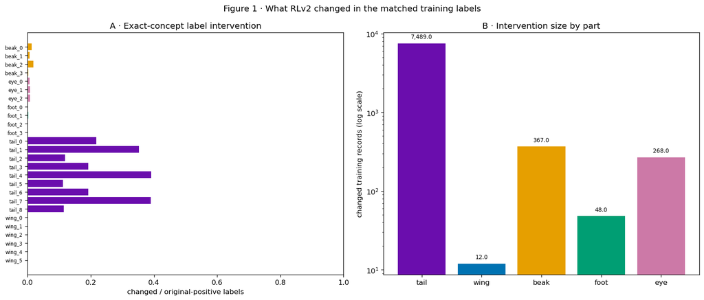

|  | concept | part | n_positive | n_changed | conflict_rate |
| --- | --- | --- | --- | --- | --- |
| 0 | beak_0 | beak | 15819 | 210 | 0.013 |
| 1 | beak_1 | beak | 7476 | 49 | 0.007 |
| 2 | beak_2 | beak | 4555 | 83 | 0.018 |
| 3 | beak_3 | beak | 9767 | 25 | 0.003 |
| 4 | eye_0 | eye | 11384 | 67 | 0.006 |
| 5 | eye_1 | eye | 11994 | 97 | 0.008 |
| 6 | eye_2 | eye | 14348 | 104 | 0.007 |
| 7 | foot_0 | foot | 9829 | 2 | 0.000 |
| 8 | foot_1 | foot | 7584 | 21 | 0.003 |
| 9 | foot_2 | foot | 10552 | 14 | 0.001 |
| 10 | foot_3 | foot | 9758 | 11 | 0.001 |
| 11 | tail_0 | tail | 3033 | 658 | 0.217 |
| 12 | tail_1 | tail | 3745 | 1320 | 0.352 |
| 13 | tail_2 | tail | 5224 | 617 | 0.118 |
| 14 | tail_3 | tail | 5285 | 1012 | 0.191 |
| 15 | tail_4 | tail | 3043 | 1190 | 0.391 |
| 16 | tail_5 | tail | 6030 | 675 | 0.112 |
| 17 | tail_6 | tail | 3752 | 722 | 0.192 |
| 18 | tail_7 | tail | 1536 | 599 | 0.390 |
| 19 | tail_8 | tail | 6059 | 696 | 0.115 |
| 20 | wing_0 | wing | 3774 | 1 | 0.000 |
| 21 | wing_1 | wing | 6815 | 2 | 0.000 |
| 22 | wing_2 | wing | 8190 | 3 | 0.000 |
| 23 | wing_3 | wing | 3794 | 0 | 0.000 |
| 24 | wing_4 | wing | 7611 | 1 | 0.000 |
| 25 | wing_5 | wing | 7504 | 5 | 0.001 |

| part | n_positive | n_changed | conflict_rate |
| --- | --- | --- | --- |
| tail | 37707 | 7489 | 0.199 |
| wing | 37688 | 12 | 0.000 |
| beak | 37617 | 367 | 0.010 |
| foot | 37723 | 48 | 0.001 |
| eye | 37726 | 268 | 0.007 |

|  | record_index | image | concept | standard_label | RLv2_label |
| --- | --- | --- | --- | --- | --- |
| tail | 1 | train/0/000001.png | tail_4 | 1 | 0 |
| eye | 7 | train/0/000008.png | eye_1 | 1 | 0 |
| beak | 162 | train/0/000184.png | beak_3 | 1 | 0 |
| foot | 1406 | train/1/001558.png | foot_2 | 1 | 0 |
| wing | 2007 | train/2/002233.png | wing_1 | 1 | 0 |

```python
# ALT: Exact and part-level FunnyBird training-label changes plus one concrete changed record for each part.
INPUT_BASE=CURATED/"koh_joint_inputs"/"funnybirds"
STD_PKLS=INPUT_BASE/"standard"; RL_PKLS=INPUT_BASE/"rlv2"
std_train=[]; rl_train=[]
for split in ["train","val"]:
    with open(STD_PKLS/f"{split}.pkl","rb") as f: std_train.extend(pickle.load(f))
    with open(RL_PKLS/f"{split}.pkl","rb") as f: rl_train.extend(pickle.load(f))
if len(std_train)!=len(rl_train): raise RuntimeError("matched train+validation lengths differ")

positive=np.zeros(len(CONCEPT_NAMES),dtype=int); changed=np.zeros(len(CONCEPT_NAMES),dtype=int)
examples={}
for idx,(a,b) in enumerate(zip(std_train,rl_train)):
    ca=np.asarray(a["attribute_label"]); cb=np.asarray(b["attribute_label"])
    positive+=(ca==1); changed+=((ca==1)&(cb==0))
    for j in np.flatnonzero((ca==1)&(cb==0)):
        part=CONCEPT_PART[CONCEPT_NAMES[j]]
        if part not in examples:
            examples[part]={"record_index":idx,"image":a.get("image",a.get("img_path")),
                            "concept":CONCEPT_NAMES[j],"standard_label":int(ca[j]),"RLv2_label":int(cb[j])}
EXACT_CONFLICT=pd.DataFrame({"concept":CONCEPT_NAMES,"part":[CONCEPT_PART[n] for n in CONCEPT_NAMES],
                             "n_positive":positive,"n_changed":changed})
EXACT_CONFLICT["conflict_rate"]=EXACT_CONFLICT.n_changed/EXACT_CONFLICT.n_positive.replace(0,np.nan)
PART_CONFLICT=EXACT_CONFLICT.groupby("part").agg(n_positive=("n_positive","sum"),n_changed=("n_changed","sum")).reindex(ORDER)
PART_CONFLICT["conflict_rate"]=PART_CONFLICT.n_changed/PART_CONFLICT.n_positive

fig,axes=plt.subplots(1,2,figsize=(14,6))
d=EXACT_CONFLICT.sort_values(["part","concept"]); y=np.arange(len(d))
axes[0].barh(y,d.conflict_rate,color=d.part.map(COLORS)); axes[0].set_yticks(y,d.concept,fontsize=7)
axes[0].invert_yaxis(); axes[0].set_xlim(0,1); axes[0].set_xlabel("changed / original-positive labels")
axes[0].set_title("A · Exact-concept label intervention")
axes[1].bar(PART_CONFLICT.index,PART_CONFLICT.n_changed,color=[COLORS[p] for p in PART_CONFLICT.index])
axes[1].set_yscale("log"); axes[1].set_ylabel("changed training records (log scale)")
axes[1].set_title("B · Intervention size by part")
for x,(p,row) in enumerate(PART_CONFLICT.iterrows()): axes[1].text(x,row.n_changed*1.15,f"{row.n_changed:,}",ha="center",fontsize=8)
fig.suptitle("Figure 1 · What RLv2 changed in the matched training labels")
plt.tight_layout();plt.show();display(EXACT_CONFLICT.round(3));display(PART_CONFLICT.round(3));display(pd.DataFrame(examples).T)
```

### Review record for Figure 1

- **Literal observation:** The complete executed table immediately above is the authoritative per-part/per-value result. Values are deliberately not hard-coded into the builder before the accepted converged Koh artifacts are executed.
- **Strongest alternative explanation:** Intervention size alone does not show that the trained model improved, and the exact tail variants differ substantially (0.111 to 0.391 conflict).
- **Discriminating test:** Figure 2 checks every permitted training difference; Figures 3–6 then check model health, identical renders, and behavior.
- **Limited conclusion:** ACCEPTED FOR identifying the manipulated supervision. The causal behavioral effect is not established by this figure alone.
- **Next question:** Did anything besides the concept labels differ between training regimes?

## 2 · Is RLv2 the only training difference?

**Question.** Is RLv2 the only training difference?

**Variables and prediction.** Compare the accepted Koh manifests and every non-label pickle-record field. Permitted manifest differences identify the label view, output path, and independently reached stopping checkpoint; within records, only `attribute_label` may differ. A causal label claim requires identical ordered images, record IDs, class labels, train/validation membership, and all model/training settings.

**Method.** Fail closed on the first unexpected difference and print explicit train/validation denominators.

**Numerical record.** The code cell prints the complete table used to draw the figure, including the per-part or per-value denominator. The picture is a visual summary of that table, not a separate calculation. Standard and RLv2 always use the same row identities, part order, definitions, bins, and axes unless the section explicitly says otherwise.

### Figure 2 · Is RLv2 the only training difference?

**How to read the figure.** The table has one row for configuration parity and one row for each split. Every Boolean must be true. This is an audit table, not a model-performance result.

```python
# ALT: Fail-closed standard-CBM versus CBM-RLv2 configuration and record-parity table.
def semantic_differences(a,b,path=()):
    if isinstance(a,dict) and isinstance(b,dict):
        out=[]
        for k in sorted(set(a)|set(b)):
            if k not in a or k not in b: out.append(path+(k,))
            else: out.extend(semantic_differences(a[k],b[k],path+(k,)))
        return out
    if isinstance(a,list) and isinstance(b,list):
        if len(a)!=len(b): return [path]
        return [q for i,(x,y) in enumerate(zip(a,b)) for q in semantic_differences(x,y,path+(i,))]
    return [] if a==b else [path]

model_metadata={name:json.loads((root/"SUCCESS.json").read_text()).get("metadata",{})
                for name,root in MODEL_ROOTS.items()}
scientific_keys=["framework","backbone","dataset","seed","architecture",
                 "training_protocol","loss","batch_size","optimizer"]
unexpected_metadata_differences={key:(model_metadata["standard"].get(key),model_metadata["RLv2"].get(key))
                                 for key in scientific_keys
                                 if key in model_metadata["standard"] and key in model_metadata["RLv2"]
                                 and model_metadata["standard"][key]!=model_metadata["RLv2"][key]}
if model_metadata["standard"].get("labels")!="standard" or model_metadata["RLv2"].get("labels")!="rlv2":
    raise RuntimeError("accepted manifests do not identify the Standard and RLv2 label views")
if unexpected_metadata_differences:
    raise RuntimeError(f"unexpected manifest metadata differences: {unexpected_metadata_differences}")
def value_equal(x,y):
    try:return bool(np.array_equal(np.asarray(x),np.asarray(y)))
    except:return x==y
def identity(r): return (str(r.get("image",r.get("img_path"))).replace("\\","/"),int(r["class_label"]),r.get("id"))
parity=[]
for split in ["train","val","test"]:
    with open(STD_PKLS/f"{split}.pkl","rb") as f:a=pickle.load(f)
    with open(RL_PKLS/f"{split}.pkl","rb") as f:b=pickle.load(f)
    same_len=len(a)==len(b); same_ids=same_len and [identity(r) for r in a]==[identity(r) for r in b]
    bad=[]
    if same_len:
        for i,(ra,rb) in enumerate(zip(a,b)):
            keys=set(ra)|set(rb)
            diff=[k for k in keys if k!="attribute_label" and not value_equal(ra.get(k),rb.get(k))]
            if diff: bad.append((i,diff));break
    parity.append({"check":split,"n_standard":len(a),"n_RLv2":len(b),"same_ordered_image_class_id":same_ids,
                   "same_all_non_label_fields":same_len and not bad,"first_unexpected_difference":bad[:1]})
PARITY=pd.DataFrame([{"check":"accepted manifest protocol","n_standard":np.nan,"n_RLv2":np.nan,
                      "same_ordered_image_class_id":True,"same_all_non_label_fields":not unexpected_metadata_differences,
                      "first_unexpected_difference":str(unexpected_metadata_differences)}]+parity)
display(PARITY)
if not PARITY[["same_ordered_image_class_id","same_all_non_label_fields"]].to_numpy().all():
    raise RuntimeError("training/configuration parity failed")
print("ACCEPTED FOR matched training/configuration parity")
```

|  | check | n_standard | n_RLv2 | same_ordered_image_class_id | same_all_non_label_fields | first_unexpected_difference |
| --- | --- | --- | --- | --- | --- | --- |
| 0 | accepted manifest protocol | NaN | NaN | True | True | {} |
| 1 | train | 45000.0 | 45000.0 | True | True | [] |
| 2 | val | 5000.0 | 5000.0 | True | True | [] |
| 3 | test | 500.0 | 500.0 | True | True | [] |

```
ACCEPTED FOR matched training/configuration parity
```

### Review record for Figure 2

- **Literal observation:** The complete executed table immediately above is the authoritative per-part/per-value result. Values are deliberately not hard-coded into the builder before the accepted converged Koh artifacts are executed.
- **Strongest alternative explanation:** A matched input audit cannot exclude training randomness or a failed checkpoint.
- **Discriminating test:** Figures 3–4 check both trained models and prove that their evaluation pixels are identical.
- **Limited conclusion:** ACCEPTED FOR matched seed-1 training/configuration parity. Seed replication remains separate.
- **Next question:** Were both accepted converged models usable rather than collapsed or broken?

## 3 · Did both trainings produce usable CBMs?

**Question.** Did both trainings produce usable CBMs?

**Variables and prediction.** For every exact concept and each regime, calculate raw-z spread, label separation against that regime's saved target, balanced accuracy, and positive recall. Also report species-task accuracy. Both models must have non-collapsed outputs and above-chance health; otherwise a change in swap behavior could reflect failed training.

**Method.** Read each accepted Koh final-test export, reconstruct its 500-by-26 raw-logit and label matrices, and verify that sigmoid(raw z) reproduces the exported probabilities.

**Numerical record.** The code cell prints the complete table used to draw the figure, including the per-part or per-value denominator. The picture is a visual summary of that table, not a separate calculation. Standard and RLv2 always use the same row identities, part order, definitions, bins, and axes unless the section explicitly says otherwise.

### Figure 3 · Did both trainings produce usable CBMs?

**How to read the figure.** Rows are exact concepts and columns are the same four health measures as notebook 02. Standard and RLv2 are shown separately. These are health checks, not grounding evidence.

|  | regime | images | task_accuracy | sigmoid_replay_error |
| --- | --- | --- | --- | --- |
| 0 | standard | 500 | 0.992 | 0.0 |
| 1 | RLv2 | 500 | 0.988 | 0.0 |

|  | regime | concept | part | spread | label_separation | balanced_accuracy | positive_recall |
| --- | --- | --- | --- | --- | --- | --- | --- |
| 0 | standard | beak_0 | beak | 10.054 | 8.069 | 0.994 | 0.990 |
| 1 | standard | beak_1 | beak | 12.014 | 10.326 | 0.994 | 0.990 |
| 2 | standard | beak_2 | beak | 13.487 | 11.214 | 0.999 | 1.000 |
| 3 | standard | beak_3 | beak | 11.431 | 8.898 | 0.996 | 0.992 |
| 4 | standard | eye_0 | eye | 11.156 | 9.241 | 0.989 | 0.987 |
| 5 | standard | eye_1 | eye | 10.891 | 8.934 | 0.988 | 0.975 |
| 6 | standard | eye_2 | eye | 10.699 | 8.428 | 0.985 | 0.979 |
| 7 | standard | foot_0 | foot | 11.098 | 8.940 | 0.999 | 1.000 |
| 8 | standard | foot_1 | foot | 11.551 | 9.560 | 0.995 | 0.990 |
| 9 | standard | foot_2 | foot | 11.267 | 8.639 | 0.993 | 0.986 |
| 10 | standard | foot_3 | foot | 11.026 | 8.596 | 0.995 | 0.992 |
| 11 | standard | tail_0 | tail | 13.528 | 11.872 | 1.000 | 1.000 |
| 12 | standard | tail_1 | tail | 13.152 | 11.078 | 0.969 | 0.940 |
| 13 | standard | tail_2 | tail | 13.100 | 10.605 | 0.999 | 1.000 |
| 14 | standard | tail_3 | tail | 13.254 | 11.034 | 1.000 | 1.000 |
| 15 | standard | tail_4 | tail | 12.265 | 10.878 | 0.988 | 0.975 |
| 16 | standard | tail_5 | tail | 13.036 | 10.256 | 0.993 | 0.988 |
| 17 | standard | tail_6 | tail | 13.616 | 11.742 | 1.000 | 1.000 |
| 18 | standard | tail_7 | tail | 5.907 | 12.483 | 1.000 | 1.000 |
| 19 | standard | tail_8 | tail | 12.384 | 10.342 | 0.986 | 0.975 |
| 20 | standard | wing_0 | wing | 13.371 | 11.684 | 1.000 | 1.000 |
| 21 | standard | wing_1 | wing | 12.410 | 10.088 | 1.000 | 1.000 |
| 22 | standard | wing_2 | wing | 11.227 | 9.239 | 1.000 | 1.000 |
| 23 | standard | wing_3 | wing | 12.718 | 10.861 | 1.000 | 1.000 |
| 24 | standard | wing_4 | wing | 11.393 | 9.322 | 0.995 | 0.990 |
| 25 | standard | wing_5 | wing | 11.569 | 9.618 | 1.000 | 1.000 |
| 26 | RLv2 | beak_0 | beak | 10.490 | 8.469 | 0.988 | 0.985 |
| 27 | RLv2 | beak_1 | beak | 12.317 | 10.198 | 0.995 | 0.990 |
| 28 | RLv2 | beak_2 | beak | 13.312 | 11.118 | 1.000 | 1.000 |
| 29 | RLv2 | beak_3 | beak | 12.178 | 9.419 | 1.000 | 1.000 |
| 30 | RLv2 | eye_0 | eye | 12.144 | 9.588 | 0.987 | 0.980 |
| 31 | RLv2 | eye_1 | eye | 12.212 | 9.567 | 0.986 | 0.981 |
| 32 | RLv2 | eye_2 | eye | 11.750 | 9.346 | 0.985 | 0.979 |
| 33 | RLv2 | foot_0 | foot | 10.829 | 8.753 | 0.999 | 1.000 |
| 34 | RLv2 | foot_1 | foot | 11.651 | 9.866 | 1.000 | 1.000 |
| 35 | RLv2 | foot_2 | foot | 10.918 | 8.590 | 0.982 | 0.964 |
| 36 | RLv2 | foot_3 | foot | 10.820 | 8.634 | 0.995 | 0.992 |
| 37 | RLv2 | tail_0 | tail | 13.909 | 12.802 | 0.984 | 0.968 |
| 38 | RLv2 | tail_1 | tail | 13.151 | 12.378 | 0.984 | 0.971 |
| 39 | RLv2 | tail_2 | tail | 13.022 | 10.347 | 0.981 | 0.967 |
| 40 | RLv2 | tail_3 | tail | 13.466 | 11.121 | 0.967 | 0.949 |
| 41 | RLv2 | tail_4 | tail | 6.694 | 12.856 | 0.976 | 0.955 |
| 42 | RLv2 | tail_5 | tail | 12.842 | 9.989 | 0.987 | 0.986 |
| 43 | RLv2 | tail_6 | tail | 13.627 | 11.962 | 1.000 | 1.000 |
| 44 | RLv2 | tail_7 | tail | 4.832 | 14.263 | 0.950 | 0.900 |
| 45 | RLv2 | tail_8 | tail | 12.542 | 10.289 | 0.985 | 0.972 |
| 46 | RLv2 | wing_0 | wing | 13.290 | 11.624 | 0.990 | 0.980 |
| 47 | RLv2 | wing_1 | wing | 12.391 | 10.275 | 0.999 | 1.000 |
| 48 | RLv2 | wing_2 | wing | 11.152 | 9.279 | 1.000 | 1.000 |
| 49 | RLv2 | wing_3 | wing | 12.931 | 10.998 | 1.000 | 1.000 |
| 50 | RLv2 | wing_4 | wing | 11.976 | 9.309 | 0.999 | 1.000 |
| 51 | RLv2 | wing_5 | wing | 11.812 | 9.964 | 0.995 | 0.990 |

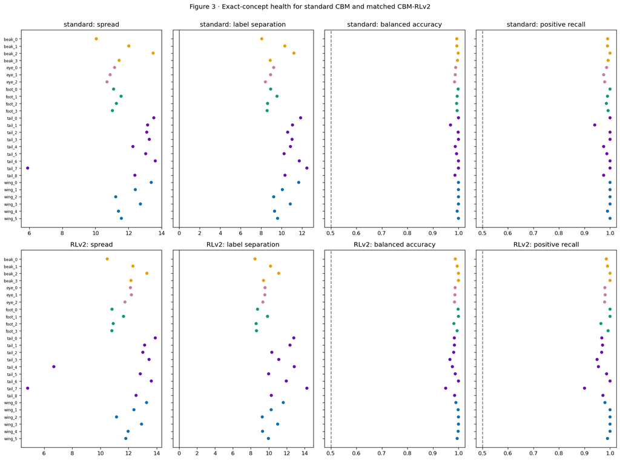

```python
# ALT: Standard and RLv2 exact-concept raw-score spread, label separation, balanced accuracy, and positive recall.
def balanced_accuracy(y,p):
    y=np.asarray(y).astype(int);p=np.asarray(p).astype(int)
    return np.nanmean([(p[y==1]==1).mean() if (y==1).any() else np.nan,
                       (p[y==0]==0).mean() if (y==0).any() else np.nan])
PRED_DATA={};health=[];health_summary=[]
for regime,root in MODEL_ROOTS.items():
    pred_path=root/"final_test.parquet"
    if not pred_path.is_file(): raise FileNotFoundError(pred_path)
    d=pd.read_parquet(pred_path)
    needed={"image","y_true","y_pred","concept_index","concept_name","z","prob","gt_label"}
    if missing:=needed-set(d): raise RuntimeError(f"{regime} evaluation lacks {sorted(missing)}")
    image_order=d.image.drop_duplicates().tolist()
    z=d.pivot(index="image",columns="concept_index",values="z").reindex(image_order).to_numpy()
    c=d.pivot(index="image",columns="concept_index",values="gt_label").reindex(image_order).to_numpy()
    labels=(d[["image","y_true","y_pred"]].drop_duplicates("image").set_index("image").reindex(image_order))
    y=labels.y_true.to_numpy(int); yp=labels.y_pred.to_numpy(int)
    probabilities=d.pivot(index="image",columns="concept_index",values="prob").reindex(image_order).to_numpy()
    sigmoid_error=float(np.max(np.abs(probabilities-1/(1+np.exp(-z)))))
    if sigmoid_error>1e-5: raise RuntimeError(f"{regime} sigmoid/raw-z mismatch: {sigmoid_error}")
    PRED_DATA[regime]={"z":z,"c":c,"y":y,"y_pred":yp,"pred_path":pred_path}
    health_summary.append({"regime":regime,"images":len(y),
                           "task_accuracy":(yp==y).mean(),"sigmoid_replay_error":sigmoid_error})
    for j,name in enumerate(CONCEPT_NAMES):
        zz=z[:,j];cc=c[:,j].astype(int);pred=(zz>0).astype(int)
        health.append({"regime":regime,"concept":name,"part":CONCEPT_PART[name],
          "spread":np.quantile(zz,.95)-np.quantile(zz,.05),
          "label_separation":np.median(zz[cc==1])-np.median(zz[cc==0]),
          "balanced_accuracy":balanced_accuracy(cc,pred),"positive_recall":pred[cc==1].mean()})
HEALTH=pd.DataFrame(health);display(pd.DataFrame(health_summary).round(5));display(HEALTH.round(3))
fig,axes=plt.subplots(2,4,figsize=(16,12),sharey="row")
metrics=["spread","label_separation","balanced_accuracy","positive_recall"]
for r,regime in enumerate(["standard","RLv2"]):
    d=HEALTH[HEALTH.regime==regime].sort_values(["part","concept"]);y=np.arange(len(d))
    for ax,m in zip(axes[r],metrics):
        ax.scatter(d[m],y,c=d.part.map(COLORS),s=22);ax.set_title(f"{regime}: {m.replace('_',' ')}")
        if m=="label_separation":ax.axvline(0,color="black",lw=.8)
        if m in ["balanced_accuracy","positive_recall"]:ax.axvline(.5,color="gray",ls="--")
    axes[r,0].set_yticks(y,d.concept,fontsize=7);axes[r,0].invert_yaxis()
fig.suptitle("Figure 3 · Exact-concept health for standard CBM and matched CBM-RLv2")
plt.tight_layout(rect=[0,0,1,.98]);plt.show()
```

### Review record for Figure 3

- **Literal observation:** The complete executed table immediately above is the authoritative per-part/per-value result. Values are deliberately not hard-coded into the builder before the accepted converged Koh artifacts are executed.
- **Strongest alternative explanation:** The relabeling can still change raw-logit scale or individual variants even though neither model collapsed.
- **Discriminating test:** Figures 5–11 use sign-based controlled events, paired component scores, and exact-value recognition on identical renders.
- **Limited conclusion:** ACCEPTED FOR model health. The small task-accuracy difference does not explain the part-specific controlled pattern by itself.
- **Next question:** Were the two models evaluated on exactly the same valid rendered images?

## 4 · Are the fixed-render comparisons pixel-identical?

**Question.** Are the fixed-render comparisons pixel-identical?

**Variables and prediction.** Check one-to-one render IDs, original hashes, counterfactual hashes, part, direction, source/donor identities, exact values, and visible-pixel counts. Every identity must match before a score difference is attributed to training labels.

**Method.** Display the accepted renderer preflight and print the full paired-image audit.

**Numerical record.** The code cell prints the complete table used to draw the figure, including the per-part or per-value denominator. The picture is a visual summary of that table, not a separate calculation. Standard and RLv2 always use the same row identities, part order, definitions, bins, and axes unless the section explicitly says otherwise.

### Figure 4 · Are the fixed-render comparisons pixel-identical?

**How to read the figure.** The image shows original, replacement, deletion, and part maps for all parts. The table reports 5,000 paired rows and Boolean identity checks. This is an intervention audit, not a behavioral result.

|  | paired_rows | unique_render_ids | unique_counterfactual_hashes | all_counterfactual_hashes_match | all_original_hashes_match | parts | directions |
| --- | --- | --- | --- | --- | --- | --- | --- |
| 0 | 5000 | 5000 | 3040 | True | True | beak,eye,foot,tail,wing | bwd,fwd |

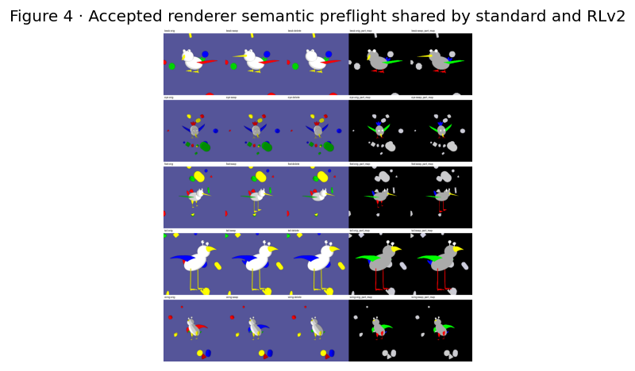

```python
# ALT: Validated all-part FunnyBird renderer preflight plus identical-render audit for the standard/RLv2 pair.
audit=pd.DataFrame([{"paired_rows":len(Q),"unique_render_ids":Q.render_id.nunique(),
 "unique_counterfactual_hashes":Q.image_cf_sha256_standard.nunique(),
 "all_counterfactual_hashes_match":(Q.image_cf_sha256_standard==Q.image_cf_sha256_rl).all(),
 "all_original_hashes_match":(Q.image_orig_sha256_standard==Q.image_orig_sha256_rl).all(),
 "parts":",".join(sorted(Q.part.unique())),"directions":",".join(sorted(Q.direction.unique()))}])
display(audit)
if len(Q)!=5000 or not audit[["all_counterfactual_hashes_match","all_original_hashes_match"]].to_numpy().all():
    raise RuntimeError("fixed-render parity failed")
preflight=SWAP_DIR/"renderer_preflight"/"renderer_semantic_preflight.png"
if not preflight.exists():raise FileNotFoundError(preflight)
fig,ax=plt.subplots(figsize=(15,4));ax.imshow(Image.open(preflight).convert("RGB"));ax.axis("off")
ax.set_title("Figure 4 · Accepted renderer semantic preflight shared by standard and RLv2")
plt.tight_layout();plt.show()
```

### Review record for Figure 4

- **Literal observation:** The complete executed table immediately above is the authoritative per-part/per-value result. Values are deliberately not hard-coded into the builder before the accepted converged Koh artifacts are executed.
- **Strongest alternative explanation:** Renderer validity does not guarantee that relabeling improves grounding.
- **Discriminating test:** Figure 5 evaluates both models on these identical pixels.
- **Limited conclusion:** ACCEPTED FOR fixed-render evaluation parity and the limited one-part replacement claim.
- **Next question:** Did changing only the labels reduce the controlled candidate event?

## 5 · Did RLv2 reduce controlled backwash on identical swaps?

**Question.** Did RLv2 reduce controlled backwash on identical swaps?

**Variables and prediction.** For each part and regime, plot final margin `m_cf` and the rate satisfying both `response_delta>0` and `m_cf<0`. Tail should improve most; beak and eye may improve modestly; foot and wing should remain similar.

**Method.** Use the exact same 1,000 swaps per part and pair rows by render ID and image hash.

**Numerical record.** The code cell prints the complete table used to draw the figure, including the per-part or per-value denominator. The picture is a visual summary of that table, not a separate calculation. Standard and RLv2 always use the same row identities, part order, definitions, bins, and axes unless the section explicitly says otherwise.

### Figure 5 · Did RLv2 reduce controlled backwash on identical swaps?

**How to read the figure.** Panel A shows final-margin distributions; values right of zero favor the donor. Panel B shows the complete candidate rate. A lower RLv2 bar means fewer identical swaps responded to donor pixels yet still preferred the removed source.

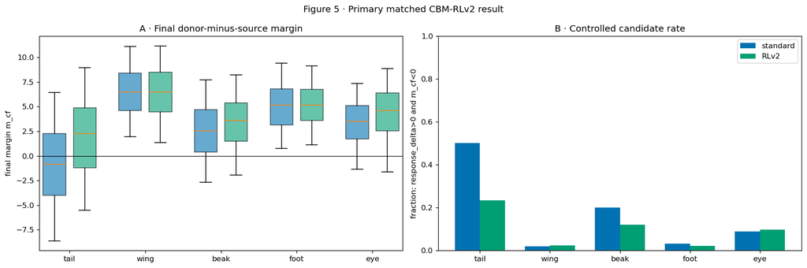

| part | standard | RLv2 | n |
| --- | --- | --- | --- |
| tail | 0.502 | 0.234 | 1000 |
| wing | 0.019 | 0.023 | 1000 |
| beak | 0.200 | 0.120 | 1000 |
| foot | 0.032 | 0.022 | 1000 |
| eye | 0.089 | 0.098 | 1000 |

```python
# ALT: Paired standard-CBM and CBM-RLv2 final margins and controlled candidate-event rates for every part.
fig,axes=plt.subplots(1,2,figsize=(15,5))
positions=[];values=[];colors=[];ticks=[];labels=[];pos=1
for part in ORDER:
    for regime,suffix in [("standard","standard"),("RLv2","rl")]:
        positions.append(pos);values.append(Q.loc[Q.part==part,f"margin_{suffix}"]);colors.append(REGIME_COLORS[regime]);pos+=1
    ticks.append(pos-1.5);labels.append(part);pos+=.5
bp=axes[0].boxplot(values,positions=positions,widths=.75,showfliers=False,whis=(5,95),patch_artist=True)
for b,c in zip(bp["boxes"],colors):b.set_facecolor(c);b.set_alpha(.6)
axes[0].axhline(0,color="black",lw=.8);axes[0].set_xticks(ticks,labels);axes[0].set_ylabel("final margin m_cf")
axes[0].set_title("A · Final donor-minus-source margin")
rates=[]
for part in ORDER:
    d=Q[Q.part==part];rates.append({"part":part,"standard":d.candidate_standard.mean(),"RLv2":d.candidate_rl.mean(),"n":len(d)})
PRIMARY=pd.DataFrame(rates).set_index("part").reindex(ORDER);x=np.arange(len(ORDER));w=.36
axes[1].bar(x-w/2,PRIMARY.standard,w,color=REGIME_COLORS["standard"],label="standard")
axes[1].bar(x+w/2,PRIMARY.RLv2,w,color=REGIME_COLORS["RLv2"],label="RLv2")
axes[1].set_xticks(x,ORDER);axes[1].set_ylim(0,1);axes[1].set_ylabel("fraction: response_delta>0 and m_cf<0")
axes[1].set_title("B · Controlled candidate rate");axes[1].legend()
fig.suptitle("Figure 5 · Primary matched CBM-RLv2 result")
plt.tight_layout();plt.show();display(PRIMARY.round(3))
```

### Review record for Figure 5

- **Literal observation:** The complete executed table immediately above is the authoritative per-part/per-value result. Values are deliberately not hard-coded into the builder before the accepted converged Koh artifacts are executed.
- **Strongest alternative explanation:** A lower aggregate rate could hide many newly introduced cases or reciprocal-direction cancellation.
- **Discriminating test:** Figure 6 counts every transition; Figures 9–10 separate direction and inserted-part pixel count.
- **Limited conclusion:** Use the paired table to distinguish large changes from small ones. Tail and beak are the preregistered primary comparisons; small wing, foot, or eye differences remain unresolved training-seed variation until matched seeds exist.
- **Next question:** Which standard candidate events were resolved, remained, or were newly introduced?

### Notebook-02 Figure 4b · Standard model's three mutually exclusive outcomes

The Standard figure is retained exactly because a transition plot answers a different question. The next figure repeats this same three-outcome construction for RLv2 before examining Standard-to-RLv2 transitions.

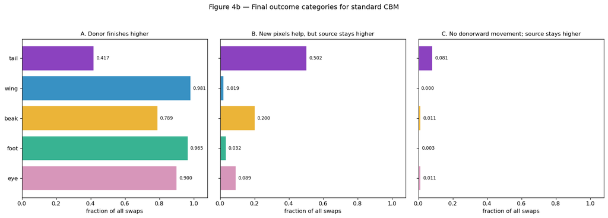

## 5b · What are the same three complete outcome fractions under RLv2?

**Question.** What are the same three complete outcome fractions under RLv2?

**Variables and prediction.** Place every RLv2 swap into exactly one category: donor finishes higher; donorward movement occurs but source stays higher; or no donorward movement occurs and source stays higher. If the relabeling improves grounding, the donor-win fraction should rise and one or both source-retaining fractions should fall.

**Method.** Apply the exact Figure-4b sign rules to the same 1,000 swaps per part, changing only the model's saved margins.

**Numerical record.** The code cell prints the complete table used to draw the figure, including the per-part or per-value denominator. The picture is a visual summary of that table, not a separate calculation. Standard and RLv2 always use the same row identities, part order, definitions, bins, and axes unless the section explicitly says otherwise.

### Figure 5b · What are the same three complete outcome fractions under RLv2?

**How to read the figure.** This is the RLv2 counterpart to the exact Standard image immediately above. Each panel uses all 1,000 swaps per part, and its three values sum to one.

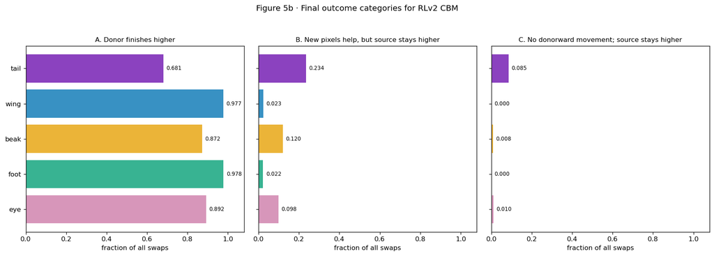

|  | donor_wins | helped_but_source_wins | no_donorward_move_and_source_wins |
| --- | --- | --- | --- |
| tail | 0.681 | 0.234 | 0.085 |
| wing | 0.977 | 0.023 | 0.000 |
| beak | 0.872 | 0.120 | 0.008 |
| foot | 0.978 | 0.022 | 0.000 |
| eye | 0.892 | 0.098 | 0.010 |

```python
# ALT: RLv2 donor-win, donorward-but-source-still-wins, and no-donorward-movement fractions using the exact Standard Figure-4b construction.
RL_OUTCOMES=pd.DataFrame(index=ORDER,dtype=float)
RL_OUTCOMES["donor_wins"]=(Q.m_cf_rl>0).groupby(Q.part).mean().reindex(ORDER)
RL_OUTCOMES["helped_but_source_wins"]=((Q.m_cf_rl<=0)&(Q.response_delta_rl>0)).groupby(Q.part).mean().reindex(ORDER)
RL_OUTCOMES["no_donorward_move_and_source_wins"]=((Q.m_cf_rl<=0)&(Q.response_delta_rl<=0)).groupby(Q.part).mean().reindex(ORDER)
if not np.allclose(RL_OUTCOMES.sum(axis=1),1):
    raise RuntimeError("RLv2 three-outcome fractions do not sum to one")
panels=[("donor_wins","A. Donor finishes higher"),
        ("helped_but_source_wins","B. New pixels help, but source stays higher"),
        ("no_donorward_move_and_source_wins","C. No donorward movement; source stays higher")]
fig,axes=plt.subplots(1,3,figsize=(15,5.4),sharey=True)
for ax,(column,title) in zip(axes.flat,panels):
    values=RL_OUTCOMES[column];y=np.arange(len(ORDER))
    ax.barh(y,values.values,color=[COLORS[p] for p in ORDER],alpha=.78)
    ax.set_title(title,fontsize=10);ax.set_xlim(0,1.08);ax.set_yticks(y,ORDER);ax.invert_yaxis()
    for yy,value in enumerate(values):ax.text(value+.015,yy,f"{value:.3f}",va="center",fontsize=8)
    ax.set_xlabel("fraction of all swaps")
fig.suptitle("Figure 5b · Final outcome categories for RLv2 CBM")
plt.tight_layout(rect=[0,0,1,.94]);plt.show();display(RL_OUTCOMES.round(3))
```

### Review record for Figure 5b

- **Literal observation:** The complete executed table immediately above is the authoritative per-part/per-value result. Values are deliberately not hard-coded into the builder before the accepted converged Koh artifacts are executed.
- **Strongest alternative explanation:** A part-average change can hide which identical rows improved, remained candidates, or became new candidates.
- **Discriminating test:** Figure 6 follows with the row-paired transition partition.
- **Limited conclusion:** This is the exact RLv2 counterpart to Standard Figure 4b; interpretation must use all three mutually exclusive outcomes, not only the donor-win rate.
- **Next question:** Which identical rows moved between the Standard and RLv2 outcome definitions?

## 6 · Which individual swap outcomes changed?

**Question.** Which individual swap outcomes changed?

**Variables and prediction.** Classify every paired row as resolved, remaining, introduced, or never a candidate using the unchanged candidate predicate. A useful intervention should resolve more standard events than it introduces, especially for tail.

**Method.** Count transitions on identical render IDs and report both all-row rates and the conditional resolution rate among standard candidates.

**Numerical record.** The code cell prints the complete table used to draw the figure, including the per-part or per-value denominator. The picture is a visual summary of that table, not a separate calculation. Standard and RLv2 always use the same row identities, part order, definitions, bins, and axes unless the section explicitly says otherwise.

### Figure 6 · Which individual swap outcomes changed?

**How to read the figure.** Each bar partitions all swaps for a part into four mutually exclusive states. `Resolved` means standard was a candidate and RLv2 was not; `introduced` is the reverse. The table prints the exact denominators.

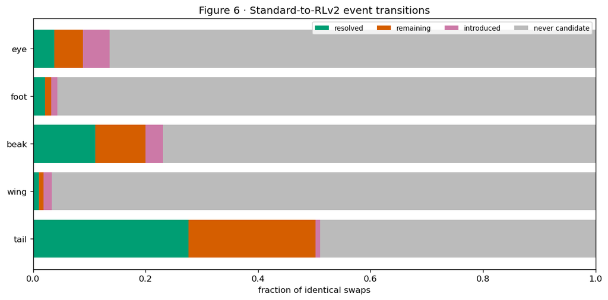

| transition part | resolved | remaining | introduced | never candidate | standard_candidates | resolution_rate_among_standard_candidates | net_candidate_change |
| --- | --- | --- | --- | --- | --- | --- | --- |
| tail | 276 | 226 | 8 | 490 | 502 | 0.549801 | -268 |
| wing | 10 | 9 | 14 | 967 | 19 | 0.526316 | 4 |
| beak | 111 | 89 | 31 | 769 | 200 | 0.555000 | -80 |
| foot | 21 | 11 | 11 | 957 | 32 | 0.656250 | -10 |
| eye | 38 | 51 | 47 | 864 | 89 | 0.426966 | 9 |

```python
# ALT: Resolved, remaining, introduced, and never-candidate transitions for every identical FunnyBird swap.
cats=["resolved","remaining","introduced","never candidate"]
TRANS=(Q.groupby(["part","transition"]).size().unstack(fill_value=0).reindex(index=ORDER,columns=cats,fill_value=0))
TRANS_RATE=TRANS.div(TRANS.sum(1),axis=0)
TRANS["standard_candidates"]=TRANS.resolved+TRANS.remaining
TRANS["resolution_rate_among_standard_candidates"]=TRANS.resolved/TRANS.standard_candidates.replace(0,np.nan)
TRANS["net_candidate_change"]=TRANS.introduced-TRANS.resolved
fig,ax=plt.subplots(figsize=(10,5));left=np.zeros(len(ORDER));palette={"resolved":"#009E73","remaining":"#D55E00","introduced":"#CC79A7","never candidate":"#BBBBBB"}
for c in cats:
    ax.barh(ORDER,TRANS_RATE[c],left=left,label=c,color=palette[c]);left+=TRANS_RATE[c].to_numpy()
ax.set_xlim(0,1);ax.set_xlabel("fraction of identical swaps");ax.set_title("Figure 6 · Standard-to-RLv2 event transitions")
ax.legend(ncol=4,fontsize=8);plt.tight_layout();plt.show();display(TRANS)
```

### Review record for Figure 6

- **Literal observation:** The complete executed table immediately above is the authoritative per-part/per-value result. Values are deliberately not hard-coded into the builder before the accepted converged Koh artifacts are executed.
- **Strongest alternative explanation:** The standard-to-RLv2 contrast is one training seed; small net changes may reflect retraining variability or shared-encoder spillover.
- **Discriminating test:** Figures 7–11 test the score mechanism and robustness within seed 1; matched seeds 2–3 are still required for reproducibility.
- **Limited conclusion:** RLv2 resolves a real subset rather than merely shifting an average, but it neither removes all candidates nor avoids new ones.
- **Next question:** Did RLv2 work by suppressing the removed source, raising the donor, or both?

## 7 · Which raw concept score changed?

**Question.** Which raw concept score changed?

**Variables and prediction.** For every paired swap compute `ΔD_cf=D_cf_RLv2-D_cf_standard`, `ΔS_cf=S_cf_RLv2-S_cf_standard`, and `Δm_cf=m_cf_RLv2-m_cf_standard`. The proposed mechanism predicts a negative `ΔS_cf` and positive `Δm_cf`, strongest for tail. `ΔD_cf` is less certain.

**Method.** Average paired changes by part and retain the row-level distributions in the table.

**Numerical record.** The code cell prints the complete table used to draw the figure, including the per-part or per-value denominator. The picture is a visual summary of that table, not a separate calculation. Standard and RLv2 always use the same row identities, part order, definitions, bins, and axes unless the section explicitly says otherwise.

### Figure 7 · Which raw concept score changed?

**How to read the figure.** Negative removed-source change means RLv2 turned off the concept that was removed. Positive donor change means it strengthened the inserted concept. Positive margin change means the donor gained relative to the source.

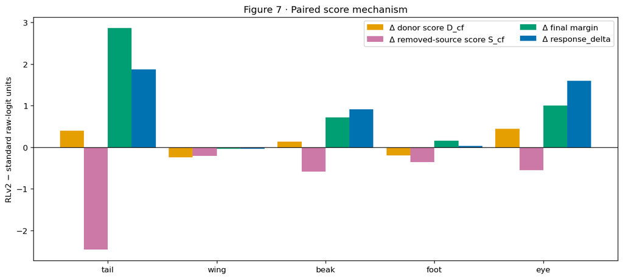

| part | delta_donor_cf | delta_source_cf | delta_final_margin | delta_response |
| --- | --- | --- | --- | --- |
| tail | 0.401 | -2.459 | 2.859 | 1.869 |
| wing | -0.247 | -0.213 | -0.034 | -0.038 |
| beak | 0.133 | -0.587 | 0.720 | 0.908 |
| foot | -0.202 | -0.360 | 0.158 | 0.033 |
| eye | 0.446 | -0.553 | 0.999 | 1.598 |

```python
# ALT: Paired changes in inserted-donor score, removed-source score, final margin, and response delta.
MECH_ROWS=[]
for part,d in Q.groupby("part"):
    MECH_ROWS.append({"part":part,"delta_donor_cf":(d.z_new_rl-d.z_new_standard).mean(),
      "delta_source_cf":(d.z_old_rl-d.z_old_standard).mean(),
      "delta_final_margin":(d.margin_rl-d.margin_standard).mean(),
      "delta_response":(d.response_delta_rl-d.response_delta_standard).mean()})
MECH=pd.DataFrame(MECH_ROWS).set_index("part").reindex(ORDER);x=np.arange(len(ORDER));w=.22
fig,ax=plt.subplots(figsize=(11,5));ax.bar(x-1.5*w,MECH.delta_donor_cf,w,label="Δ donor score D_cf",color="#E69F00")
ax.bar(x-.5*w,MECH.delta_source_cf,w,label="Δ removed-source score S_cf",color="#CC79A7")
ax.bar(x+.5*w,MECH.delta_final_margin,w,label="Δ final margin",color="#009E73")
ax.bar(x+1.5*w,MECH.delta_response,w,label="Δ response_delta",color="#0072B2")
ax.axhline(0,color="black",lw=.8);ax.set_xticks(x,ORDER);ax.set_ylabel("RLv2 − standard raw-logit units")
ax.set_title("Figure 7 · Paired score mechanism");ax.legend(ncol=2);plt.tight_layout();plt.show();display(MECH.round(3))
```

### Review record for Figure 7

- **Literal observation:** The complete executed table immediately above is the authoritative per-part/per-value result. Values are deliberately not hard-coded into the builder before the accepted converged Koh artifacts are executed.
- **Strongest alternative explanation:** Raw-logit magnitudes from separately trained models can also reflect scale recalibration, and `response_delta` includes an RLv2-shifted original margin.
- **Discriminating test:** Figure 8 checks within-model donorward response and Figure 11 checks sign-free exact donor-value recognition.
- **Limited conclusion:** ACCEPTED FOR the predicted donor-up/source-down mechanism in tail and directionally in beak/eye, not as a universal RLv2 mechanism.
- **Next question:** Did RLv2 change the complete original-to-swap response, or mainly the final preference?

### Notebook-02 Figure 3b · Standard starting preference and swap-response decomposition

The exact Standard figure is shown before the denser matched decomposition because the matched heatmap changes the construction substantially. The following RLv2 section retains every Standard quantity and adds a second regime row.

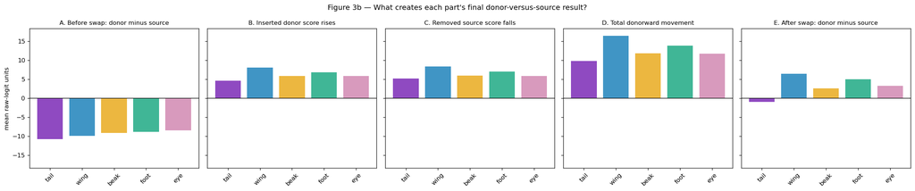

## 7b · Which part of the starting preference and swap response did RLv2 change?

**Question.** Which part of the starting preference and swap response did RLv2 change?

**Variables and prediction.** For each regime, decompose `m_cf = m_orig + donor_gain + source_decrease`, while also showing `D_orig` and `S_orig` separately. All quantities are post-head raw logits `z`, not internal `h`. If visibility-inconsistent labels help preserve a removed concept, RLv2 should increase `source_decrease` and improve `m_cf` most where the manipulated conflict was largest. It may also change `D_orig`, `S_orig`, and donor gain because the complete shared encoder is retrained.

**Method.** Use the same 5,000 paired render IDs for both models, average each component by part, verify the decomposition row by row, and print `RLv2-standard` changes.

**Numerical record.** The code cell prints the complete table used to draw the figure, including the per-part or per-value denominator. The picture is a visual summary of that table, not a separate calculation. Standard and RLv2 always use the same row identities, part order, definitions, bins, and axes unless the section explicitly says otherwise.

### Figure 7b · Which part of the starting preference and swap response did RLv2 change?

**How to read the figure.** Rows are standard and RLv2; columns are the same five parts. Panels A-B show the two original-image scores, Panel C their starting margin, Panels D-E the two swap-response components, Panel F their sum, and Panel G the final margin. Blue means negative and red means positive within the shared raw-logit scale. The table below the figure prints the exact means and paired regime differences.

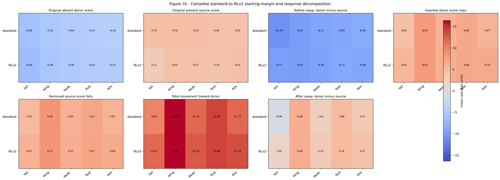

| component | regime | tail | wing | beak | foot | eye |
| --- | --- | --- | --- | --- | --- | --- |
| D_orig | standard | -6.057 | -5.217 | -4.640 | -4.429 | -4.184 |
|  | RLv2 | -6.656 | -5.463 | -4.983 | -4.623 | -4.565 |
| S_orig | standard | 4.699 | 4.697 | 4.527 | 4.418 | 4.297 |
|  | RLv2 | 3.109 | 4.446 | 4.372 | 4.099 | 4.515 |
| m_orig | standard | -10.756 | -9.914 | -9.167 | -8.847 | -8.481 |
|  | RLv2 | -9.766 | -9.909 | -9.355 | -8.722 | -9.080 |
| donor_gain | standard | 4.599 | 8.029 | 5.842 | 6.804 | 5.875 |
|  | RLv2 | 5.599 | 8.028 | 6.318 | 6.796 | 6.702 |
| source_decrease | standard | 5.201 | 8.361 | 5.936 | 7.027 | 5.874 |
|  | RLv2 | 6.070 | 8.323 | 6.368 | 7.068 | 6.645 |
| response_delta | standard | 9.800 | 16.390 | 11.778 | 13.831 | 11.749 |
|  | RLv2 | 11.669 | 16.351 | 12.686 | 13.864 | 13.347 |
| m_cf | standard | -0.956 | 6.476 | 2.611 | 4.984 | 3.268 |
|  | RLv2 | 1.903 | 6.442 | 3.331 | 5.142 | 4.267 |

**RLv2 minus standard (positive and negative retain each component's defined direction):**

|  | tail | wing | beak | foot | eye |
| --- | --- | --- | --- | --- | --- |
| D_orig | -0.599 | -0.246 | -0.343 | -0.194 | -0.381 |
| S_orig | -1.590 | -0.251 | -0.155 | -0.319 | 0.217 |
| m_orig | 0.990 | 0.005 | -0.188 | 0.125 | -0.599 |
| donor_gain | 1.000 | -0.000 | 0.476 | -0.008 | 0.827 |
| source_decrease | 0.869 | -0.038 | 0.432 | 0.041 | 0.770 |
| response_delta | 1.869 | -0.038 | 0.908 | 0.033 | 1.598 |
| m_cf | 2.859 | -0.034 | 0.720 | 0.158 | 0.999 |

```python
# ALT: Matched standard-CBM and RLv2 original donor/source scores, starting margin, donor gain, source decrease, total response, and final margin for every FunnyBird part.
component_specs=[
    ("D_orig","Original absent-donor score"),
    ("S_orig","Original present-source score"),
    ("m_orig","Before swap: donor minus source"),
    ("donor_gain","Inserted donor score rises"),
    ("source_decrease","Removed source score falls"),
    ("response_delta","Total movement toward donor"),
    ("m_cf","After swap: donor minus source"),
]
column_map={
    "D_orig":("z_new_orig_standard","z_new_orig_rl"),
    "S_orig":("z_old_orig_standard","z_old_orig_rl"),
    "m_orig":("m_orig_standard","m_orig_rl"),
    "donor_gain":("donor_gain_standard","donor_gain_rl"),
    "source_decrease":("source_decrease_standard","source_decrease_rl"),
    "response_delta":("response_delta_standard","response_delta_rl"),
    "m_cf":("m_cf_standard","m_cf_rl"),
}
component_tables={}
for key,_ in component_specs:
    table=pd.DataFrame(index=["standard","RLv2"],columns=ORDER,dtype=float)
    standard_col,rl_col=column_map[key]
    table.loc["standard"]=Q.groupby("part")[standard_col].mean().reindex(ORDER)
    table.loc["RLv2"]=Q.groupby("part")[rl_col].mean().reindex(ORDER)
    component_tables[key]=table
for suffix in ["standard","rl"]:
    err=np.max(np.abs(Q[f"m_cf_{suffix}"]-(Q[f"m_orig_{suffix}"]+Q[f"donor_gain_{suffix}"]+Q[f"source_decrease_{suffix}"])))
    if err>1e-8: raise RuntimeError(f"{suffix} decomposition error {err}")
lim=max(float(np.nanmax(np.abs(t.values))) for t in component_tables.values())
fig,axes=plt.subplots(2,4,figsize=(22,8));axes=axes.ravel()
for ax,(key,title) in zip(axes,component_specs):
    table=component_tables[key]
    im=ax.imshow(table.values,aspect="auto",cmap="coolwarm",vmin=-lim,vmax=lim)
    ax.set_xticks(range(len(ORDER)),ORDER,rotation=40,ha="right")
    ax.set_yticks(range(2),table.index);ax.set_title(title,fontsize=10)
    for r in range(2):
        for c in range(len(ORDER)):
            ax.text(c,r,f"{table.iloc[r,c]:.2f}",ha="center",va="center",fontsize=8)
axes[-1].axis("off")
fig.colorbar(im,ax=axes[:-1].tolist(),label="mean raw-logit units",fraction=.02,pad=.02)
fig.suptitle("Figure 7b · Complete standard-to-RLv2 starting-margin and response decomposition")
plt.tight_layout();plt.show()
display(pd.concat(component_tables,names=["component","regime"]).round(3))
paired_changes=pd.DataFrame({key:table.loc["RLv2"]-table.loc["standard"]
                             for key,table in component_tables.items()}).T
display(Markdown("**RLv2 minus standard (positive and negative retain each component's defined direction):**"))
display(paired_changes.round(3))
```

### What this decomposition can and cannot isolate

| Proposed factor | Component it could affect | Test in this notebook | Causal status |
| --- | --- | --- | --- |
| visibility-inconsistent training labels | any component after retraining; predicted most directly to improve removed-source release | matched RLv2 versus standard on identical renders | causal for the complete relabeling package at seed 1; not isolated to one part because the encoder is shared |
| inserted-part visibility/area | mainly donor gain, possibly source release | Figure 10, same rows stratified by exact target pixels | association within validated swaps; area itself was not randomized |
| exact source/donor value | starting margin and both response components | Figure 11 and value-matched residuals | controlled description, not an independent frequency intervention |
| unchanged source species/body | especially removed-source persistence and final margin | Figures 12 and 14 | observational; source species is not independently manipulated |
| retraining randomness | every component | matched seeds 2-3 | currently incomplete |

Figure 7b identifies **where the numerical change occurs**. Only the matched label intervention identifies a manipulated cause, and even that intervention retrained the complete shared encoder. It therefore tests whether the label package contributes to the behavior, not whether each changed tail label acts only on the tail output.

## 8 · Did original-to-swap donorward movement change?

**Question.** Did original-to-swap donorward movement change?

**Variables and prediction.** Compare standard and RLv2 `response_delta=m_cf-m_orig` distributions and positive-response rates. RLv2 may strengthen donorward movement, but this is secondary because the original-image margin is also intentionally changed.

**Method.** Use identical rows and show every part.

**Numerical record.** The code cell prints the complete table used to draw the figure, including the per-part or per-value denominator. The picture is a visual summary of that table, not a separate calculation. Standard and RLv2 always use the same row identities, part order, definitions, bins, and axes unless the section explicitly says otherwise.

### Figure 8 · Did original-to-swap donorward movement change?

**How to read the figure.** The boxes show response_delta; above zero means the replacement moved the comparison toward the donor. The bars show the fraction above zero. This does not by itself say whether the donor finishes above the source.

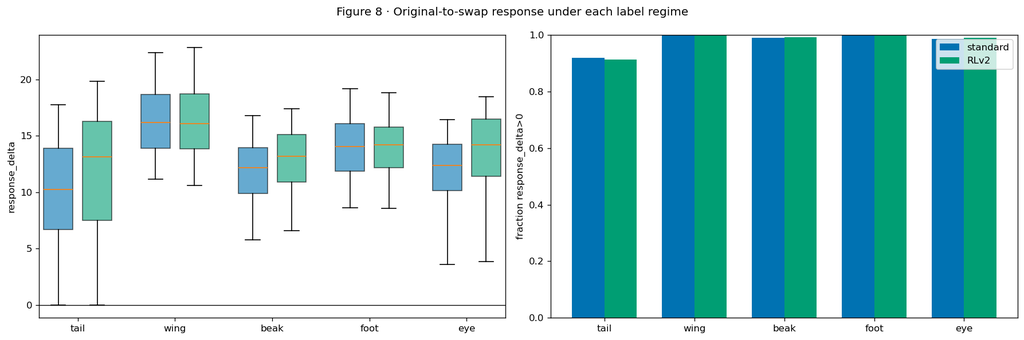

| part | standard | RLv2 |
| --- | --- | --- |
| tail | 0.919 | 0.914 |
| wing | 1.000 | 1.000 |
| beak | 0.989 | 0.992 |
| foot | 0.997 | 1.000 |
| eye | 0.986 | 0.990 |

```python
# ALT: Standard and RLv2 response-delta distributions and positive donor-response rates.
fig,axes=plt.subplots(1,2,figsize=(15,5));positions=[];values=[];colors=[];ticks=[];pos=1
for part in ORDER:
    for regime,suffix in [("standard","standard"),("RLv2","rl")]:
        positions.append(pos);values.append(Q.loc[Q.part==part,f"response_delta_{suffix}"]);colors.append(REGIME_COLORS[regime]);pos+=1
    ticks.append(pos-1.5);pos+=.5
bp=axes[0].boxplot(values,positions=positions,widths=.75,showfliers=False,whis=(5,95),patch_artist=True)
for b,c in zip(bp["boxes"],colors):b.set_facecolor(c);b.set_alpha(.6)
axes[0].axhline(0,color="black",lw=.8);axes[0].set_xticks(ticks,ORDER);axes[0].set_ylabel("response_delta")
rates=[]
for part,d in Q.groupby("part"):
    rates.append({"part":part,"standard":(d.response_delta_standard>0).mean(),"RLv2":(d.response_delta_rl>0).mean()})
RESPONSE=pd.DataFrame(rates).set_index("part").reindex(ORDER);x=np.arange(len(ORDER));w=.36
axes[1].bar(x-w/2,RESPONSE.standard,w,color=REGIME_COLORS["standard"],label="standard")
axes[1].bar(x+w/2,RESPONSE.RLv2,w,color=REGIME_COLORS["RLv2"],label="RLv2")
axes[1].set_xticks(x,ORDER);axes[1].set_ylim(0,1);axes[1].set_ylabel("fraction response_delta>0");axes[1].legend()
fig.suptitle("Figure 8 · Original-to-swap response under each label regime")
plt.tight_layout();plt.show();display(RESPONSE.round(3))
```

### Review record for Figure 8

- **Literal observation:** The complete executed table immediately above is the authoritative per-part/per-value result. Values are deliberately not hard-coded into the builder before the accepted converged Koh artifacts are executed.
- **Strongest alternative explanation:** Because RLv2 changes the original-image margin as well as the counterfactual margin, `response_delta` need not track the primary final-preference change.
- **Discriminating test:** Use the paired final margin and event transition as primary endpoints; retain `response_delta` only to prove that inserted pixels are still detected.
- **Limited conclusion:** RLv2 does not work by making swaps more detectable. It mainly changes the final donor-versus-source preference, especially for tail.
- **Next question:** Does the primary result hold in both replacement directions?

## 9 · Could one swap direction create the RLv2 result?

**Question.** Could one swap direction create the RLv2 result?

**Variables and prediction.** Calculate the unchanged candidate predicate separately for forward and backward replacements under each regime. A real part-level label effect should not depend entirely on one arbitrary direction.

**Method.** Keep direction and regime separate and print 500-row denominators.

**Numerical record.** The code cell prints the complete table used to draw the figure, including the per-part or per-value denominator. The picture is a visual summary of that table, not a separate calculation. Standard and RLv2 always use the same row identities, part order, definitions, bins, and axes unless the section explicitly says otherwise.

### Figure 9 · Could one swap direction create the RLv2 result?

**How to read the figure.** Circles and squares distinguish standard and RLv2; solid and dashed lines distinguish forward and backward swaps. Lower candidate rates are better.

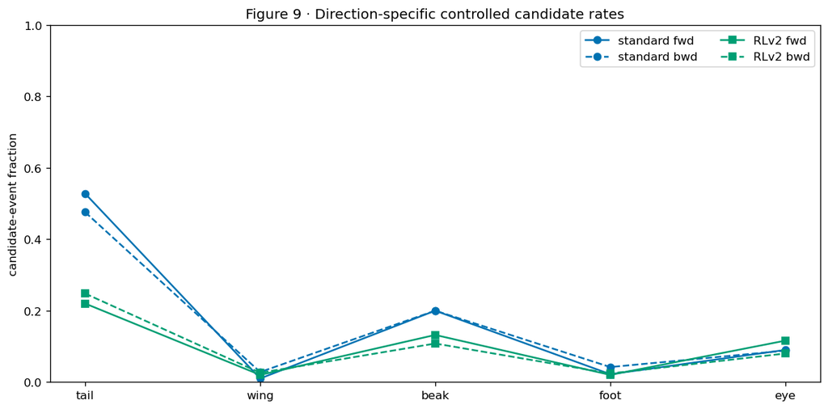

|  | part | direction | n | standard | RLv2 |
| --- | --- | --- | --- | --- | --- |
| 0 | beak | bwd | 500 | 0.200 | 0.108 |
| 1 | beak | fwd | 500 | 0.200 | 0.132 |
| 2 | eye | bwd | 500 | 0.088 | 0.080 |
| 3 | eye | fwd | 500 | 0.090 | 0.116 |
| 4 | foot | bwd | 500 | 0.042 | 0.024 |
| 5 | foot | fwd | 500 | 0.022 | 0.020 |
| 6 | tail | bwd | 500 | 0.476 | 0.248 |
| 7 | tail | fwd | 500 | 0.528 | 0.220 |
| 8 | wing | bwd | 500 | 0.028 | 0.026 |
| 9 | wing | fwd | 500 | 0.010 | 0.020 |

```python
# ALT: Forward and backward controlled candidate-event rates for standard CBM and matched CBM-RLv2.
rows=[]
for (part,direction),d in Q.groupby(["part","direction"]):
    rows.append({"part":part,"direction":direction,"n":len(d),"standard":d.candidate_standard.mean(),"RLv2":d.candidate_rl.mean()})
DIRECTION=pd.DataFrame(rows);fig,ax=plt.subplots(figsize=(10,5))
for regime,marker in [("standard","o"),("RLv2","s")]:
    for direction,ls in [("fwd","-"),("bwd","--")]:
        d=DIRECTION[DIRECTION.direction==direction].set_index("part").reindex(ORDER)
        ax.plot(ORDER,d[regime],marker=marker,ls=ls,color=REGIME_COLORS[regime],label=f"{regime} {direction}")
ax.set_ylim(0,1);ax.set_ylabel("candidate-event fraction");ax.set_title("Figure 9 · Direction-specific controlled candidate rates")
ax.legend(ncol=2);plt.tight_layout();plt.show();display(DIRECTION.round(3))
```

### Review record for Figure 9

- **Literal observation:** The complete executed table immediately above is the authoritative per-part/per-value result. Values are deliberately not hard-coded into the builder before the accepted converged Koh artifacts are executed.
- **Strongest alternative explanation:** Different exact variants within a direction could still respond unequally.
- **Discriminating test:** Figures 10–11 stratify by visible pixel count and exact inserted value.
- **Limited conclusion:** ACCEPTED FOR ruling out opposite-direction cancellation as the aggregate explanation.
- **Next question:** Is any improvement confined to swaps where the inserted part has little or no visible area?

## 10 · How does exact inserted-part visibility change the RLv2 result?

**Question.** How does exact inserted-part visibility change the RLv2 result?

**Variables and prediction.** Within the same declared pixel-count bins as notebook 02, compare standard and RLv2 candidate rates. If RLv2 only changes zero-pixel cases, it did not improve recognition of visible donor evidence. Improvement among clearly visible rows supports a broader label-training effect.

**Method.** Use exact counterfactual part-map pixel counts and print row denominators for every bin.

**Numerical record.** The code cell prints the complete table used to draw the figure, including the per-part or per-value denominator. The picture is a visual summary of that table, not a separate calculation. Standard and RLv2 always use the same row identities, part order, definitions, bins, and axes unless the section explicitly says otherwise.

### Figure 10 · How does exact inserted-part visibility change the RLv2 result?

**How to read the figure.** Each panel is one part. The x-axis is visible inserted-part pixels and the y-axis is the complete candidate rate. Standard and RLv2 share the same rows in every bin.

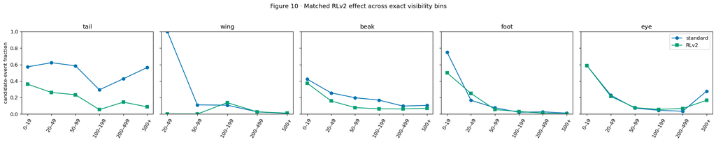

|  | part | visibility_bin | n | standard | RLv2 |
| --- | --- | --- | --- | --- | --- |
| 0 | beak | 0–19 | 123 | 0.423 | 0.374 |
| 1 | beak | 20–49 | 164 | 0.256 | 0.159 |
| 2 | beak | 50–99 | 192 | 0.198 | 0.078 |
| 3 | beak | 100–199 | 237 | 0.169 | 0.063 |
| 4 | beak | 200–499 | 227 | 0.097 | 0.062 |
| 5 | beak | 500+ | 57 | 0.105 | 0.070 |
| 6 | eye | 0–19 | 17 | 0.588 | 0.588 |
| 7 | eye | 20–49 | 136 | 0.228 | 0.213 |
| 8 | eye | 50–99 | 307 | 0.072 | 0.078 |
| 9 | eye | 100–199 | 285 | 0.046 | 0.056 |
| 10 | eye | 200–499 | 237 | 0.034 | 0.068 |
| 11 | eye | 500+ | 18 | 0.278 | 0.167 |
| 12 | foot | 0–19 | 4 | 0.750 | 0.500 |
| 13 | foot | 20–49 | 12 | 0.167 | 0.250 |
| 14 | foot | 50–99 | 92 | 0.076 | 0.054 |
| 15 | foot | 100–199 | 228 | 0.022 | 0.031 |
| 16 | foot | 200–499 | 489 | 0.027 | 0.010 |
| 17 | foot | 500+ | 175 | 0.011 | 0.000 |
| 18 | tail | 0–19 | 386 | 0.573 | 0.363 |
| 19 | tail | 20–49 | 130 | 0.623 | 0.262 |
| 20 | tail | 50–99 | 94 | 0.585 | 0.234 |
| 21 | tail | 100–199 | 187 | 0.294 | 0.053 |
| 22 | tail | 200–499 | 180 | 0.428 | 0.144 |
| 23 | tail | 500+ | 23 | 0.565 | 0.087 |
| 24 | wing | 20–49 | 1 | 1.000 | 0.000 |
| 25 | wing | 50–99 | 9 | 0.111 | 0.000 |
| 26 | wing | 100–199 | 65 | 0.108 | 0.138 |
| 27 | wing | 200–499 | 224 | 0.027 | 0.027 |
| 28 | wing | 500+ | 701 | 0.006 | 0.011 |

```python
# ALT: Per-part standard/RLv2 candidate rates across exact swapped-part visibility bins.
bins=[0,20,50,100,200,500,np.inf];labels=["0–19","20–49","50–99","100–199","200–499","500+"]
W=Q.copy();W["visibility_bin"]=pd.cut(W.pixel_count_cf,bins=bins,labels=labels,right=False)
rows=[]
for (part,v),d in W.groupby(["part","visibility_bin"],observed=True):
    rows.append({"part":part,"visibility_bin":v,"n":len(d),"standard":d.candidate_standard.mean(),"RLv2":d.candidate_rl.mean()})
VIS=pd.DataFrame(rows);fig,axes=plt.subplots(1,5,figsize=(20,4),sharey=True)
for ax,part in zip(axes,ORDER):
    d=VIS[VIS.part==part].set_index("visibility_bin").reindex(labels)
    ax.plot(labels,d.standard,"o-",color=REGIME_COLORS["standard"],label="standard")
    ax.plot(labels,d.RLv2,"s-",color=REGIME_COLORS["RLv2"],label="RLv2")
    ax.set_title(part);ax.tick_params(axis="x",rotation=60);ax.set_ylim(0,1)
axes[0].set_ylabel("candidate-event fraction");axes[-1].legend()
fig.suptitle("Figure 10 · Matched RLv2 effect across exact visibility bins")
plt.tight_layout(rect=[0,0,1,.95]);plt.show();display(VIS.round(3))
```

### Review record for Figure 10

- **Literal observation:** The complete executed table immediately above is the authoritative per-part/per-value result. Values are deliberately not hard-coded into the builder before the accepted converged Koh artifacts are executed.
- **Strongest alternative explanation:** Sparse extreme bins and exact-value composition can make individual bin estimates unstable.
- **Discriminating test:** Figure 11 compares exact donor values directly; seed-level replication is required for uncertainty.
- **Limited conclusion:** The tail/beak improvement is not confined to nearly invisible inserted parts. The visible-pixel result is not universal across parts.
- **Next question:** Did RLv2 improve exact donor-value recognition, or do particular variants remain difficult?

## 11 · Did exact inserted-value recognition improve?

**Question.** Did exact inserted-value recognition improve?

**Variables and prediction.** For every part and regime, compare the inserted donor value with the highest post-swap raw concept logit. If RLv2 repairs broad label conflict but not visual-value difficulty, tail recognition may improve while particular rows remain poor.

**Method.** Display all exact values in two aligned rows: standard and RLv2.

**Numerical record.** The code cell prints the complete table used to draw the figure, including the per-part or per-value denominator. The picture is a visual summary of that table, not a separate calculation. Standard and RLv2 always use the same row identities, part order, definitions, bins, and axes unless the section explicitly says otherwise.

### Figure 11 · Did exact inserted-value recognition improve?

**How to read the figure.** Each heatmap row is the inserted value and each column is the highest-scoring value. A brighter diagonal means better exact donor recognition. The title prints the full diagonal rate.

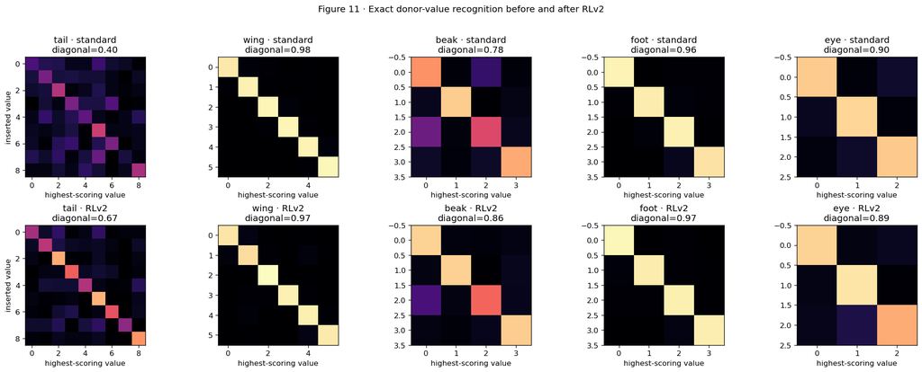

|  | regime | part | donor_value | n | recognition_rate | candidate_rate |
| --- | --- | --- | --- | --- | --- | --- |
| 0 | standard | tail | 0 | 75 | 0.240 | 0.640 |
| 1 | standard | tail | 1 | 90 | 0.344 | 0.533 |
| 2 | standard | tail | 2 | 120 | 0.492 | 0.408 |
| 3 | standard | tail | 3 | 110 | 0.355 | 0.573 |
| 4 | standard | tail | 4 | 110 | 0.282 | 0.518 |
| 5 | standard | tail | 5 | 150 | 0.553 | 0.373 |
| 6 | standard | tail | 6 | 130 | 0.354 | 0.515 |
| 7 | standard | tail | 7 | 35 | 0.114 | 0.800 |
| 8 | standard | tail | 8 | 180 | 0.467 | 0.478 |
| 9 | standard | wing | 0 | 130 | 0.954 | 0.031 |
| 10 | standard | wing | 1 | 150 | 0.973 | 0.027 |
| 11 | standard | wing | 2 | 220 | 0.982 | 0.009 |
| 12 | standard | wing | 3 | 115 | 0.983 | 0.017 |
| 13 | standard | wing | 4 | 175 | 0.977 | 0.023 |
| 14 | standard | wing | 5 | 210 | 0.986 | 0.014 |
| 15 | standard | beak | 0 | 345 | 0.771 | 0.200 |
| 16 | standard | beak | 1 | 245 | 0.898 | 0.098 |
| 17 | standard | beak | 2 | 190 | 0.595 | 0.363 |
| 18 | standard | beak | 3 | 220 | 0.823 | 0.173 |
| 19 | standard | foot | 0 | 220 | 0.977 | 0.009 |
| 20 | standard | foot | 1 | 240 | 0.962 | 0.038 |
| 21 | standard | foot | 2 | 290 | 0.976 | 0.024 |
| 22 | standard | foot | 3 | 250 | 0.944 | 0.056 |
| 23 | standard | eye | 0 | 300 | 0.893 | 0.100 |
| 24 | standard | eye | 1 | 345 | 0.916 | 0.072 |
| 25 | standard | eye | 2 | 355 | 0.890 | 0.096 |
| 26 | RLv2 | tail | 0 | 75 | 0.453 | 0.453 |
| 27 | RLv2 | tail | 1 | 90 | 0.511 | 0.367 |
| 28 | RLv2 | tail | 2 | 120 | 0.825 | 0.117 |
| 29 | RLv2 | tail | 3 | 110 | 0.664 | 0.200 |
| 30 | RLv2 | tail | 4 | 110 | 0.482 | 0.355 |
| 31 | RLv2 | tail | 5 | 150 | 0.840 | 0.107 |
| 32 | RLv2 | tail | 6 | 130 | 0.631 | 0.238 |
| 33 | RLv2 | tail | 7 | 35 | 0.400 | 0.486 |
| 34 | RLv2 | tail | 8 | 180 | 0.778 | 0.156 |
| 35 | RLv2 | wing | 0 | 130 | 0.946 | 0.015 |
| 36 | RLv2 | wing | 1 | 150 | 0.933 | 0.060 |
| 37 | RLv2 | wing | 2 | 220 | 1.000 | 0.000 |
| 38 | RLv2 | wing | 3 | 115 | 0.974 | 0.009 |
| 39 | RLv2 | wing | 4 | 175 | 0.971 | 0.023 |
| 40 | RLv2 | wing | 5 | 210 | 0.957 | 0.033 |
| 41 | RLv2 | beak | 0 | 345 | 0.910 | 0.061 |
| 42 | RLv2 | beak | 1 | 245 | 0.906 | 0.090 |
| 43 | RLv2 | beak | 2 | 190 | 0.679 | 0.289 |
| 44 | RLv2 | beak | 3 | 220 | 0.895 | 0.100 |
| 45 | RLv2 | foot | 0 | 220 | 0.986 | 0.000 |
| 46 | RLv2 | foot | 1 | 240 | 0.962 | 0.033 |
| 47 | RLv2 | foot | 2 | 290 | 0.972 | 0.021 |
| 48 | RLv2 | foot | 3 | 250 | 0.968 | 0.032 |
| 49 | RLv2 | eye | 0 | 300 | 0.907 | 0.083 |
| 50 | RLv2 | eye | 1 | 345 | 0.948 | 0.049 |
| 51 | RLv2 | eye | 2 | 355 | 0.825 | 0.158 |

```python
# ALT: All-part exact donor-value confusion matrices for standard CBM and matched CBM-RLv2.
def concept_columns(frame,part):
    return sorted([c for c in frame if c.startswith(f"z_cf_{part}_")],key=lambda x:int(x.rsplit("_",1)[1]))
VALUE_ROWS=[];DIAG={}
fig,axes=plt.subplots(2,5,figsize=(18,7))
for r,(regime,frame) in enumerate([("standard",STD),("RLv2",RL)]):
    for c,part in enumerate(ORDER):
        d=frame[frame.part==part];cols=concept_columns(d,part);pred=d[cols].to_numpy().argmax(1);donor=d.var_donor.astype(int).to_numpy()
        n=len(cols);M=np.zeros((n,n))
        for a,b in zip(donor,pred):M[a,b]+=1
        M=M/np.maximum(M.sum(1,keepdims=True),1);DIAG[(regime,part)]=(pred==donor).mean()
        axes[r,c].imshow(M,cmap="magma",vmin=0,vmax=1);axes[r,c].set_title(f"{part} · {regime}\ndiagonal={DIAG[(regime,part)]:.2f}")
        axes[r,c].set_xlabel("highest-scoring value");
        if c==0:axes[r,c].set_ylabel("inserted value")
        for value,g in d.assign(pred=pred).groupby("var_donor"):
            VALUE_ROWS.append({"regime":regime,"part":part,"donor_value":int(value),"n":len(g),
              "recognition_rate":(g.pred==g.var_donor).mean(),"candidate_rate":g.candidate.mean()})
fig.suptitle("Figure 11 · Exact donor-value recognition before and after RLv2")
plt.tight_layout(rect=[0,0,1,.96]);plt.show();VALUE=pd.DataFrame(VALUE_ROWS);display(VALUE.round(3))
```

### Review record for Figure 11

- **Literal observation:** The complete executed table immediately above is the authoritative per-part/per-value result. Values are deliberately not hard-coded into the builder before the accepted converged Koh artifacts are executed.
- **Strongest alternative explanation:** Highest-logit recognition ignores the size of the winning margin and can hide value-specific heterogeneity.
- **Discriminating test:** Retain the per-value matrices and compare them with final-margin and source-species residual results.
- **Limited conclusion:** RLv2 improves donor-value identification most for tail and beak, but does not eliminate exact-value difficulty.
- **Next question:** After exact values, direction, and visibility are controlled, does source species still organize the margin?

## 12 · Does source species still organize the remaining margin?

**Question.** Does source species still organize the remaining margin?

**Variables and prediction.** For each regime, subtract the mean margin within `(part, source value, donor value, direction, visibility bin)` and average the residual by source species. If RLv2 removes label conflict but not unchanged-body context, species residual spread should remain even if it becomes smaller for tail.

**Method.** Require at least five rows per displayed source-species estimate and use identical control strata.

**Numerical record.** The code cell prints the complete table used to draw the figure, including the per-part or per-value denominator. The picture is a visual summary of that table, not a separate calculation. Standard and RLv2 always use the same row identities, part order, definitions, bins, and axes unless the section explicitly says otherwise.

### Figure 12 · Does source species still organize the remaining margin?

**How to read the figure.** Each panel is a part. Source species are ordered by the standard residual; blue is standard and green is RLv2 for the same species. Zero means that species matches its controlled-stratum average.

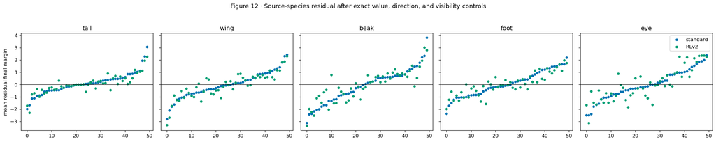

| regime part | RLv2 | standard |
| --- | --- | --- |
| tail | 0.777 | 0.894 |
| wing | 1.071 | 1.054 |
| beak | 1.306 | 1.394 |
| foot | 0.919 | 1.037 |
| eye | 1.338 | 1.181 |

```python
# ALT: Matched source-species margin residuals after exact value, direction, and visibility controls.
R=Q.copy();R["vis_bin"]=pd.cut(R.pixel_count_cf,[-1,19,49,99,199,499,np.inf],labels=False)
SPECIES_TABLES={};spread=[]
for regime,suffix in [("standard","standard"),("RLv2","rl")]:
    margin=f"margin_{suffix}";d=R.copy();d["expected"]=d.groupby(["part","var_src","var_donor","direction","vis_bin"])[margin].transform("mean")
    d["residual"]=d[margin]-d.expected
    g=d.groupby(["part","sid_src"]).agg(n=("residual","size"),residual=("residual","mean")).reset_index().query("n>=5")
    SPECIES_TABLES[regime]=g
    for part,x in g.groupby("part"):spread.append({"regime":regime,"part":part,"species":len(x),"residual_sd":x.residual.std()})
SPECIES_SPREAD=pd.DataFrame(spread)
fig,axes=plt.subplots(1,5,figsize=(20,4),sharey=True)
for ax,part in zip(axes,ORDER):
    a=SPECIES_TABLES["standard"].query("part==@part").set_index("sid_src").residual.sort_values()
    b=SPECIES_TABLES["RLv2"].query("part==@part").set_index("sid_src").residual.reindex(a.index)
    x=np.arange(len(a));ax.scatter(x,a,s=16,color=REGIME_COLORS["standard"],label="standard")
    ax.scatter(x,b,s=16,color=REGIME_COLORS["RLv2"],label="RLv2");ax.axhline(0,color="black",lw=.8);ax.set_title(part)
axes[0].set_ylabel("mean residual final margin");axes[-1].legend()
fig.suptitle("Figure 12 · Source-species residual after exact value, direction, and visibility controls")
plt.tight_layout(rect=[0,0,1,.94]);plt.show();display(SPECIES_SPREAD.pivot(index="part",columns="regime",values="residual_sd").reindex(ORDER).round(3))
```

### Review record for Figure 12

- **Literal observation:** The complete executed table immediately above is the authoritative per-part/per-value result. Values are deliberately not hard-coded into the builder before the accepted converged Koh artifacts are executed.
- **Strongest alternative explanation:** These residuals are descriptive within the same data and may encode unmeasured renderer/body structure or sparse strata rather than a causal species effect.
- **Discriminating test:** Figure 14 asks whether source species improves prediction on held-out renders after the same measured controls.
- **Limited conclusion:** ACCEPTED FOR a remaining observational source-species association, reduced most for tail. It is not accepted as a held-out causal explanation.
- **Next question:** Did RLv2 reduce species information in the learned concept representation?

## 13 · Did species decodability change inside the concept vector?

**Question.** Did species decodability change inside the concept vector?

**Variables and prediction.** For each regime, train the same held-out diagnostic classifier on known labels `c` and learned raw logits `z`, using the same image split. If RLv2 reduces contextual coding, raw-z species accuracy may decrease most for tail. This remains a representation diagnostic, not grounding evidence.

**Method.** Use one fixed stratified 70/30 split and identical logistic-regression settings.

**Numerical record.** The code cell prints the complete table used to draw the figure, including the per-part or per-value denominator. The picture is a visual summary of that table, not a separate calculation. Standard and RLv2 always use the same row identities, part order, definitions, bins, and axes unless the section explicitly says otherwise.

### Figure 13 · Did species decodability change inside the concept vector?

**How to read the figure.** Each panel is one regime. Grey bars use known labels and colored bars use learned raw z. Bar height is diagnostic held-out species accuracy, not the saved CBM's task accuracy.

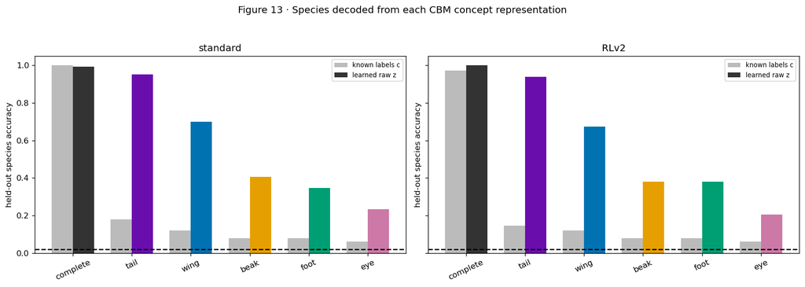

|  | regime | block | source | species_accuracy | dimensions |
| --- | --- | --- | --- | --- | --- |
| 0 | standard | complete | known labels c | 1.000 | 26 |
| 1 | standard | complete | learned raw z | 0.993 | 26 |
| 2 | standard | beak | known labels c | 0.080 | 4 |
| 3 | standard | beak | learned raw z | 0.407 | 4 |
| 4 | standard | eye | known labels c | 0.060 | 3 |
| 5 | standard | eye | learned raw z | 0.233 | 3 |
| 6 | standard | foot | known labels c | 0.080 | 4 |
| 7 | standard | foot | learned raw z | 0.347 | 4 |
| 8 | standard | tail | known labels c | 0.180 | 9 |
| 9 | standard | tail | learned raw z | 0.953 | 9 |
| 10 | standard | wing | known labels c | 0.120 | 6 |
| 11 | standard | wing | learned raw z | 0.700 | 6 |
| 12 | RLv2 | complete | known labels c | 0.973 | 26 |
| 13 | RLv2 | complete | learned raw z | 1.000 | 26 |
| 14 | RLv2 | beak | known labels c | 0.080 | 4 |
| 15 | RLv2 | beak | learned raw z | 0.380 | 4 |
| 16 | RLv2 | eye | known labels c | 0.060 | 3 |
| 17 | RLv2 | eye | learned raw z | 0.207 | 3 |
| 18 | RLv2 | foot | known labels c | 0.080 | 4 |
| 19 | RLv2 | foot | learned raw z | 0.380 | 4 |
| 20 | RLv2 | tail | known labels c | 0.147 | 9 |
| 21 | RLv2 | tail | learned raw z | 0.940 | 9 |
| 22 | RLv2 | wing | known labels c | 0.120 | 6 |
| 23 | RLv2 | wing | learned raw z | 0.673 | 6 |

```python
# ALT: Matched diagnostic species decoders using known labels and learned raw logits for standard and RLv2 CBMs.
from sklearn.model_selection import train_test_split
from sklearn.pipeline import make_pipeline
from sklearn.preprocessing import StandardScaler
from sklearn.linear_model import LogisticRegression
from sklearn.metrics import accuracy_score
probe=[]
for regime in ["standard","RLv2"]:
    z=PRED_DATA[regime]["z"];c=PRED_DATA[regime]["c"];y=PRED_DATA[regime]["y"]
    idx=np.arange(len(y));tr,te=train_test_split(idx,test_size=.30,random_state=20260803,stratify=y)
    blocks={"complete":np.arange(z.shape[1])};blocks.update({p:np.arange(lo,hi) for p,(lo,hi) in SPANS.items()})
    for block,cols in blocks.items():
        for source,X in [("known labels c",c),("learned raw z",z)]:
            model=make_pipeline(StandardScaler(),LogisticRegression(max_iter=4000,C=1,random_state=20260803))
            model.fit(X[tr][:,cols],y[tr]);probe.append({"regime":regime,"block":block,"source":source,
              "species_accuracy":accuracy_score(y[te],model.predict(X[te][:,cols])),"dimensions":len(cols)})
PROBE=pd.DataFrame(probe);fig,axes=plt.subplots(1,2,figsize=(14,5),sharey=True)
for ax,regime in zip(axes,["standard","RLv2"]):
    d=PROBE[PROBE.regime==regime];blocks=["complete"]+ORDER;x=np.arange(len(blocks));w=.36
    a=d[d.source=="known labels c"].set_index("block").reindex(blocks);b=d[d.source=="learned raw z"].set_index("block").reindex(blocks)
    ax.bar(x-w/2,a.species_accuracy,w,color="#BBBBBB",label="known labels c")
    ax.bar(x+w/2,b.species_accuracy,w,color=["#333333"]+[COLORS[p] for p in ORDER],label="learned raw z")
    ax.axhline(1/50,color="black",ls="--");ax.set_xticks(x,blocks,rotation=25);ax.set_title(regime);ax.set_ylabel("held-out species accuracy");ax.legend(fontsize=8)
fig.suptitle("Figure 13 · Species decoded from each CBM concept representation")
plt.tight_layout(rect=[0,0,1,.94]);plt.show();display(PROBE.round(3))
```

### Review record for Figure 13

- **Literal observation:** The complete executed table immediately above is the authoritative per-part/per-value result. Values are deliberately not hard-coded into the builder before the accepted converged Koh artifacts are executed.
- **Strongest alternative explanation:** This is one diagnostic split, and decodability measures available species information rather than whether a concept uses the wrong pixels.
- **Discriminating test:** Grounding conclusions must continue to come from Figures 5–11; multiple training seeds/splits are needed before treating small decoder changes as stable.
- **Limited conclusion:** VALID DIAGNOSTIC, HETEROGENEOUS CHANGE. Species information remains abundant and is neither necessary nor sufficient for poor grounding.
- **Next question:** Do visibility, exact values, or source species predict the remaining margin on held-out render IDs?

## 13a · Does label conflict align with the score component it could weaken?

**Question.** Does label conflict align with the score component it could weaken?

**Variables and prediction.** For each exact value, x is the fraction of originally positive training labels whose part was invisible. The two y quantities are the mean inserted-value rise and removed-value fall on swaps involving that same value. Values with more contradictory supervision may show weaker donor rise or weaker source release. This is an association check, not the RLv2 causal endpoint.

**Method.** Run the same diagnostic program twice. The first run reads the Standard checkpoint and Standard swap CSV. The second changes only `--regime rlv2`, which selects the RLv2 checkpoint and matched RLv2 CSV.

**Numerical record.** The code cell prints the complete table used to draw the figure, including the per-part or per-value denominator. The picture is a visual summary of that table, not a separate calculation. Standard and RLv2 always use the same row identities, part order, definitions, bins, and axes unless the section explicitly says otherwise.

### Figure 13a · Does label conflict align with the score component it could weaken?

**How to read the figure.** The Standard image appears first and the RLv2 image second because merging them would substantially change the labelled scatterplot.

```
STANDARD — same calculation
```

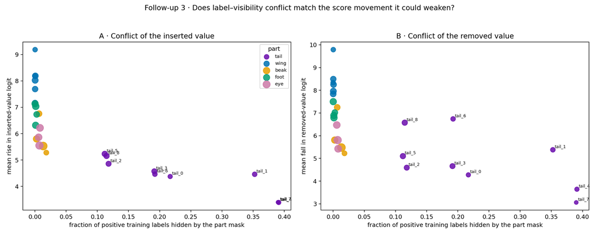

|  | concept_index | concept | part | value | positive_images | hidden_positive_images | conflict_rate | species_support | mean_donor_gain | mean_visible_pixels | donor_rows | mean_source_decrease | source_rows |
| --- | --- | --- | --- | --- | --- | --- | --- | --- | --- | --- | --- | --- | --- |
| 0 | 0 | beak_0 | beak | 0 | 15819 | 210 | 0.0133 | 21 | 5.5298 | 99.5449 | 345 | 5.4785 | 345 |
| 1 | 1 | beak_1 | beak | 1 | 7476 | 49 | 0.0066 | 10 | 6.7573 | 316.1306 | 245 | 7.2481 | 245 |
| 2 | 2 | beak_2 | beak | 2 | 4555 | 83 | 0.0182 | 6 | 5.2791 | 22.0526 | 190 | 5.2235 | 190 |
| 3 | 3 | beak_3 | beak | 3 | 9767 | 25 | 0.0026 | 13 | 5.7998 | 207.3773 | 220 | 5.8082 | 220 |
| 4 | 4 | eye_0 | eye | 0 | 11384 | 67 | 0.0059 | 15 | 5.8616 | 67.2067 | 300 | 6.4712 | 300 |
| 5 | 5 | eye_1 | eye | 1 | 11994 | 97 | 0.0081 | 16 | 6.2189 | 79.2928 | 345 | 5.4257 | 345 |
| 6 | 6 | eye_2 | eye | 2 | 14348 | 104 | 0.0072 | 19 | 5.5520 | 70.2620 | 355 | 5.8059 | 355 |
| 7 | 7 | foot_0 | foot | 0 | 9829 | 2 | 0.0002 | 13 | 7.1338 | 192.7364 | 220 | 7.4994 | 220 |
| 8 | 8 | foot_1 | foot | 1 | 7584 | 21 | 0.0028 | 10 | 6.7294 | 97.8042 | 240 | 7.0198 | 240 |
| 9 | 9 | foot_2 | foot | 2 | 10552 | 14 | 0.0013 | 14 | 7.0352 | 169.1552 | 290 | 6.7916 | 290 |
| 10 | 10 | foot_3 | foot | 3 | 9758 | 11 | 0.0011 | 13 | 6.3180 | 174.5440 | 250 | 6.8919 | 250 |
| 11 | 11 | tail_0 | tail | 0 | 3033 | 658 | 0.2169 | 4 | 4.3734 | 183.6800 | 75 | 4.2760 | 75 |
| 12 | 12 | tail_1 | tail | 1 | 3745 | 1320 | 0.3525 | 5 | 4.4579 | 115.2333 | 90 | 5.3794 | 90 |
| 13 | 13 | tail_2 | tail | 2 | 5224 | 617 | 0.1181 | 7 | 4.8566 | 83.2250 | 120 | 4.5933 | 120 |
| 14 | 14 | tail_3 | tail | 3 | 5285 | 1012 | 0.1915 | 7 | 4.5718 | 156.8545 | 110 | 4.6608 | 110 |
| 15 | 15 | tail_4 | tail | 4 | 3043 | 1190 | 0.3911 | 4 | 3.3887 | 99.7636 | 110 | 3.6440 | 110 |
| 16 | 16 | tail_5 | tail | 5 | 6030 | 675 | 0.1119 | 8 | 5.2328 | 69.1733 | 150 | 5.1008 | 150 |
| 17 | 17 | tail_6 | tail | 6 | 3752 | 722 | 0.1924 | 5 | 4.4626 | 152.8462 | 130 | 6.7392 | 130 |
| 18 | 18 | tail_7 | tail | 7 | 1536 | 599 | 0.3900 | 2 | 3.3962 | 106.6000 | 35 | 3.0609 | 35 |
| 19 | 19 | tail_8 | tail | 8 | 6059 | 696 | 0.1149 | 8 | 5.1535 | 76.7667 | 180 | 6.5735 | 180 |
| 20 | 20 | wing_0 | wing | 0 | 3774 | 1 | 0.0003 | 5 | 9.1871 | 388.9000 | 130 | 9.7883 | 130 |
| 21 | 21 | wing_1 | wing | 1 | 6815 | 2 | 0.0003 | 9 | 7.6914 | 357.4667 | 150 | 8.4944 | 150 |
| 22 | 22 | wing_2 | wing | 2 | 8190 | 3 | 0.0004 | 11 | 8.0250 | 483.9182 | 220 | 7.9594 | 220 |
| 23 | 23 | wing_3 | wing | 3 | 3794 | 0 | 0.0000 | 5 | 8.1916 | 363.8000 | 115 | 8.3381 | 115 |
| 24 | 24 | wing_4 | wing | 4 | 7611 | 1 | 0.0001 | 10 | 7.1593 | 403.3371 | 175 | 7.8375 | 175 |
| 25 | 25 | wing_5 | wing | 5 | 7504 | 5 | 0.0007 | 10 | 8.1918 | 354.1286 | 210 | 8.2514 | 210 |

```
RLV2 — same calculation
```

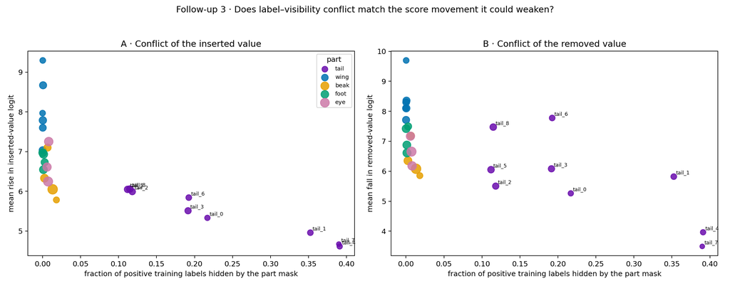

|  | concept_index | concept | part | value | positive_images | hidden_positive_images | conflict_rate | species_support | mean_donor_gain | mean_visible_pixels | donor_rows | mean_source_decrease | source_rows |
| --- | --- | --- | --- | --- | --- | --- | --- | --- | --- | --- | --- | --- | --- |
| 0 | 0 | beak_0 | beak | 0 | 15819 | 210 | 0.0133 | 21 | 6.0504 | 99.5449 | 345 | 6.0819 | 345 |
| 1 | 1 | beak_1 | beak | 1 | 7476 | 49 | 0.0066 | 10 | 7.1006 | 316.1306 | 245 | 7.1848 | 245 |
| 2 | 2 | beak_2 | beak | 2 | 4555 | 83 | 0.0182 | 6 | 5.7832 | 22.0526 | 190 | 5.8530 | 190 |
| 3 | 3 | beak_3 | beak | 3 | 9767 | 25 | 0.0026 | 13 | 6.3298 | 207.3773 | 220 | 6.3509 | 220 |
| 4 | 4 | eye_0 | eye | 0 | 11384 | 67 | 0.0059 | 15 | 6.6102 | 67.2067 | 300 | 7.1691 | 300 |
| 5 | 5 | eye_1 | eye | 1 | 11994 | 97 | 0.0081 | 16 | 7.2513 | 79.2928 | 345 | 6.1787 | 345 |
| 6 | 6 | eye_2 | eye | 2 | 14348 | 104 | 0.0072 | 19 | 6.2466 | 70.2620 | 355 | 6.6541 | 355 |
| 7 | 7 | foot_0 | foot | 0 | 9829 | 2 | 0.0002 | 13 | 6.9710 | 192.7364 | 220 | 7.4208 | 220 |
| 8 | 8 | foot_1 | foot | 1 | 7584 | 21 | 0.0028 | 10 | 6.7307 | 97.8042 | 240 | 7.4960 | 240 |
| 9 | 9 | foot_2 | foot | 2 | 10552 | 14 | 0.0013 | 14 | 6.9339 | 169.1552 | 290 | 6.6120 | 290 |
| 10 | 10 | foot_3 | foot | 3 | 9758 | 11 | 0.0011 | 13 | 6.5452 | 174.5440 | 250 | 6.8753 | 250 |
| 11 | 11 | tail_0 | tail | 0 | 3033 | 658 | 0.2169 | 4 | 5.3315 | 183.6800 | 75 | 5.2625 | 75 |
| 12 | 12 | tail_1 | tail | 1 | 3745 | 1320 | 0.3525 | 5 | 4.9590 | 115.2333 | 90 | 5.8202 | 90 |
| 13 | 13 | tail_2 | tail | 2 | 5224 | 617 | 0.1181 | 7 | 5.9914 | 83.2250 | 120 | 5.5037 | 120 |
| 14 | 14 | tail_3 | tail | 3 | 5285 | 1012 | 0.1915 | 7 | 5.5105 | 156.8545 | 110 | 6.0819 | 110 |
| 15 | 15 | tail_4 | tail | 4 | 3043 | 1190 | 0.3911 | 4 | 4.6135 | 99.7636 | 110 | 3.9645 | 110 |
| 16 | 16 | tail_5 | tail | 5 | 6030 | 675 | 0.1119 | 8 | 6.0484 | 69.1733 | 150 | 6.0520 | 150 |
| 17 | 17 | tail_6 | tail | 6 | 3752 | 722 | 0.1924 | 5 | 5.8418 | 152.8462 | 130 | 7.7764 | 130 |
| 18 | 18 | tail_7 | tail | 7 | 1536 | 599 | 0.3900 | 2 | 4.6715 | 106.6000 | 35 | 3.4929 | 35 |
| 19 | 19 | tail_8 | tail | 8 | 6059 | 696 | 0.1149 | 8 | 6.0568 | 76.7667 | 180 | 7.4723 | 180 |
| 20 | 20 | wing_0 | wing | 0 | 3774 | 1 | 0.0003 | 5 | 9.2938 | 388.9000 | 130 | 9.6958 | 130 |
| 21 | 21 | wing_1 | wing | 1 | 6815 | 2 | 0.0003 | 9 | 7.5986 | 357.4667 | 150 | 8.2991 | 150 |
| 22 | 22 | wing_2 | wing | 2 | 8190 | 3 | 0.0004 | 11 | 7.7867 | 483.9182 | 220 | 8.1013 | 220 |
| 23 | 23 | wing_3 | wing | 3 | 3794 | 0 | 0.0000 | 5 | 7.9674 | 363.8000 | 115 | 8.0987 | 115 |
| 24 | 24 | wing_4 | wing | 4 | 7611 | 1 | 0.0001 | 10 | 7.0329 | 403.3371 | 175 | 7.7108 | 175 |
| 25 | 25 | wing_5 | wing | 5 | 7504 | 5 | 0.0007 | 10 | 8.6687 | 354.1286 | 210 | 8.3555 | 210 |

```python
# ALT: Standard and RLv2 exact-value label-conflict versus matched score-response figures generated by the same code path.
from IPython.display import Image as NotebookImage
for regime in ["standard", "rlv2"]:
    print(f"{regime.upper()} — same calculation")
    display(NotebookImage(filename=str(MATCHED_FOLLOWUP_ROOT/regime/"followup3_conflict_response.png")))
    display(pd.read_csv(MATCHED_FOLLOWUP_ROOT/regime/"followup3_conflict_response.csv").round(4))
```

### Review record for Figure 13a

- **Literal observation:** The complete executed table immediately above is the authoritative per-part/per-value result. Values are deliberately not hard-coded into the builder before the accepted converged Koh artifacts are executed.
- **Strongest alternative explanation:** Conflict, visibility, species support, and exact-value difficulty are correlated properties of this generated dataset.
- **Discriminating test:** Compare the same exact values before and after relabeling and retain the matched score components rather than interpreting a part-average correlation causally.
- **Limited conclusion:** This is an exact-value association check. RLv2 supplies the intervention-level comparison; the scatter alone does not assign a causal fraction to label conflict.
- **Next question:** After holding the intervention size visible, how do rarity and all three exact-value outcomes change?

## 13b · Did RLv2 change the relationship between species support and swap outcomes?

**Question.** Did RLv2 change the relationship between species support and swap outcomes?

**Variables and prediction.** Species support is the number of the 50 species that naturally carry an exact donor value. The three mutually exclusive outcomes are donor wins, donorward movement but source remains higher, and no donorward movement while source remains higher. If relabeling repairs one contributor without changing the dataset's rarity structure, points should move vertically while their support values remain fixed.

**Method.** Apply the exact Figure-7b grouping separately to Standard and RLv2 and place the same three panels in two rows. Every row is still one of the same 5,000 fixed swaps.

**Numerical record.** The code cell prints the complete table used to draw the figure, including the per-part or per-value denominator. The picture is a visual summary of that table, not a separate calculation. Standard and RLv2 always use the same row identities, part order, definitions, bins, and axes unless the section explicitly says otherwise.

### Figure 13b · Did RLv2 change the relationship between species support and swap outcomes?

**How to read the figure.** The top row is Standard and the bottom row is RLv2. Within each column, the axes, labels, colors, support values, and outcome definitions are identical.

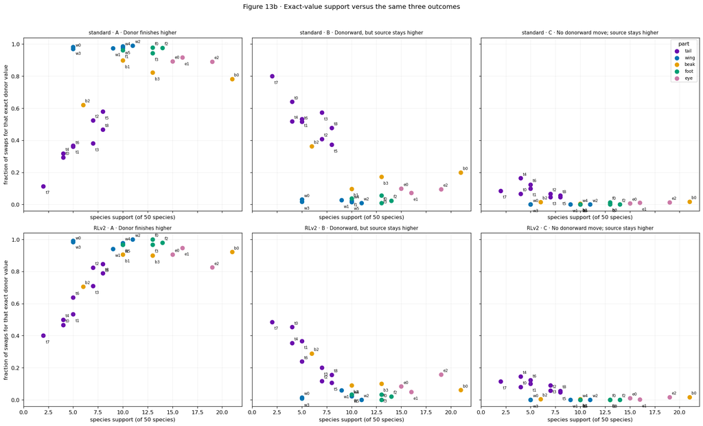

|  | part | var_donor | n_rows | species_support | donor_wins_rate | donorward_source_wins_rate | no_donorward_source_wins_rate | regime |
| --- | --- | --- | --- | --- | --- | --- | --- | --- |
| 0 | beak | 0 | 345 | 21 | 0.783 | 0.200 | 0.017 | standard |
| 1 | beak | 1 | 245 | 10 | 0.898 | 0.098 | 0.004 | standard |
| 2 | beak | 2 | 190 | 6 | 0.621 | 0.363 | 0.016 | standard |
| 3 | beak | 3 | 220 | 13 | 0.823 | 0.173 | 0.005 | standard |
| 4 | eye | 0 | 300 | 15 | 0.893 | 0.100 | 0.007 | standard |
| 5 | eye | 1 | 345 | 16 | 0.916 | 0.072 | 0.012 | standard |
| 6 | eye | 2 | 355 | 19 | 0.890 | 0.096 | 0.014 | standard |
| 7 | foot | 0 | 220 | 13 | 0.977 | 0.009 | 0.014 | standard |
| 8 | foot | 1 | 240 | 10 | 0.962 | 0.038 | 0.000 | standard |
| 9 | foot | 2 | 290 | 14 | 0.976 | 0.024 | 0.000 | standard |
| 10 | foot | 3 | 250 | 13 | 0.944 | 0.056 | 0.000 | standard |
| 11 | tail | 0 | 75 | 4 | 0.293 | 0.640 | 0.067 | standard |
| 12 | tail | 1 | 90 | 5 | 0.367 | 0.533 | 0.100 | standard |
| 13 | tail | 2 | 120 | 7 | 0.525 | 0.408 | 0.067 | standard |
| 14 | tail | 3 | 110 | 7 | 0.382 | 0.573 | 0.045 | standard |
| 15 | tail | 4 | 110 | 4 | 0.318 | 0.518 | 0.164 | standard |
| 16 | tail | 5 | 150 | 8 | 0.580 | 0.373 | 0.047 | standard |
| 17 | tail | 6 | 130 | 5 | 0.362 | 0.515 | 0.123 | standard |
| 18 | tail | 7 | 35 | 2 | 0.114 | 0.800 | 0.086 | standard |
| 19 | tail | 8 | 180 | 8 | 0.467 | 0.478 | 0.056 | standard |
| 20 | wing | 0 | 130 | 5 | 0.969 | 0.031 | 0.000 | standard |
| 21 | wing | 1 | 150 | 9 | 0.973 | 0.027 | 0.000 | standard |
| 22 | wing | 2 | 220 | 11 | 0.991 | 0.009 | 0.000 | standard |
| 23 | wing | 3 | 115 | 5 | 0.983 | 0.017 | 0.000 | standard |
| 24 | wing | 4 | 175 | 10 | 0.977 | 0.023 | 0.000 | standard |
| 25 | wing | 5 | 210 | 10 | 0.986 | 0.014 | 0.000 | standard |
| 26 | beak | 0 | 345 | 21 | 0.922 | 0.061 | 0.017 | RLv2 |
| 27 | beak | 1 | 245 | 10 | 0.906 | 0.090 | 0.004 | RLv2 |
| 28 | beak | 2 | 190 | 6 | 0.705 | 0.289 | 0.005 | RLv2 |
| 29 | beak | 3 | 220 | 13 | 0.900 | 0.100 | 0.000 | RLv2 |
| 30 | eye | 0 | 300 | 15 | 0.907 | 0.083 | 0.010 | RLv2 |
| 31 | eye | 1 | 345 | 16 | 0.948 | 0.049 | 0.003 | RLv2 |
| 32 | eye | 2 | 355 | 19 | 0.825 | 0.158 | 0.017 | RLv2 |
| 33 | foot | 0 | 220 | 13 | 1.000 | 0.000 | 0.000 | RLv2 |
| 34 | foot | 1 | 240 | 10 | 0.967 | 0.033 | 0.000 | RLv2 |
| 35 | foot | 2 | 290 | 14 | 0.979 | 0.021 | 0.000 | RLv2 |
| 36 | foot | 3 | 250 | 13 | 0.968 | 0.032 | 0.000 | RLv2 |
| 37 | tail | 0 | 75 | 4 | 0.467 | 0.453 | 0.080 | RLv2 |
| 38 | tail | 1 | 90 | 5 | 0.533 | 0.367 | 0.100 | RLv2 |
| 39 | tail | 2 | 120 | 7 | 0.825 | 0.117 | 0.058 | RLv2 |
| 40 | tail | 3 | 110 | 7 | 0.709 | 0.200 | 0.091 | RLv2 |
| 41 | tail | 4 | 110 | 4 | 0.500 | 0.355 | 0.145 | RLv2 |
| 42 | tail | 5 | 150 | 8 | 0.847 | 0.107 | 0.047 | RLv2 |
| 43 | tail | 6 | 130 | 5 | 0.638 | 0.238 | 0.123 | RLv2 |
| 44 | tail | 7 | 35 | 2 | 0.400 | 0.486 | 0.114 | RLv2 |
| 45 | tail | 8 | 180 | 8 | 0.789 | 0.156 | 0.056 | RLv2 |
| 46 | wing | 0 | 130 | 5 | 0.985 | 0.015 | 0.000 | RLv2 |
| 47 | wing | 1 | 150 | 9 | 0.940 | 0.060 | 0.000 | RLv2 |
| 48 | wing | 2 | 220 | 11 | 1.000 | 0.000 | 0.000 | RLv2 |
| 49 | wing | 3 | 115 | 5 | 0.991 | 0.009 | 0.000 | RLv2 |
| 50 | wing | 4 | 175 | 10 | 0.977 | 0.023 | 0.000 | RLv2 |
| 51 | wing | 5 | 210 | 10 | 0.967 | 0.033 | 0.000 | RLv2 |

```python
# ALT: Two identical three-panel rows showing Standard and RLv2 exact-value support against all mutually exclusive swap outcomes.
SUPPORT_OUTCOMES=[]
for regime,frame in [("standard",STD),("RLv2",RL)]:
    work=frame.assign(
        donor_wins=frame.m_cf>0,
        donorward_source_wins=(frame.m_cf<=0)&(frame.response_delta>0),
        no_donorward_source_wins=(frame.m_cf<=0)&(frame.response_delta<=0),
    )
    table=(work.groupby(["part","var_donor"]).agg(
        n_rows=("m_cf","size"),species_support=("sid_donor","nunique"),
        donor_wins_rate=("donor_wins","mean"),
        donorward_source_wins_rate=("donorward_source_wins","mean"),
        no_donorward_source_wins_rate=("no_donorward_source_wins","mean"),
    ).reset_index())
    table["regime"]=regime;SUPPORT_OUTCOMES.append(table)
SUPPORT_OUTCOMES=pd.concat(SUPPORT_OUTCOMES,ignore_index=True)
panels=[("donor_wins_rate","A · Donor finishes higher"),
        ("donorward_source_wins_rate","B · Donorward, but source stays higher"),
        ("no_donorward_source_wins_rate","C · No donorward move; source stays higher")]
fig,axes=plt.subplots(2,3,figsize=(18,11),sharex=True,sharey=True)
for row,regime in enumerate(["standard","RLv2"]):
    for axis,(column,title) in zip(axes[row],panels):
        for part in ORDER:
            d=SUPPORT_OUTCOMES.query("regime==@regime and part==@part").sort_values("var_donor")
            axis.scatter(d.species_support,d[column],s=52,color=COLORS[part],label=part)
            for k,r in enumerate(d.itertuples()):
                axis.annotate(f"{part[0]}{int(r.var_donor)}",(r.species_support,getattr(r,column)),
                              xytext=(4,5 if k%2==0 else -14),textcoords="offset points",fontsize=7)
        axis.set_title(f"{regime} · {title}",fontsize=9);axis.set_xlabel("species support (of 50 species)")
        axis.set_ylim(-.04,1.04);axis.set_xlim(0,22);axis.grid(alpha=.18)
    axes[row,0].set_ylabel("fraction of swaps for that exact donor value")
axes[0,2].legend(title="part",fontsize=8)
fig.suptitle("Figure 13b · Exact-value support versus the same three outcomes")
plt.tight_layout(rect=[0,0,1,.96]);plt.show();display(SUPPORT_OUTCOMES.round(3))
```

### Review record for Figure 13b

- **Literal observation:** The complete executed table immediately above is the authoritative per-part/per-value result. Values are deliberately not hard-coded into the builder before the accepted converged Koh artifacts are executed.
- **Strongest alternative explanation:** Low support can coincide with tail identity, visibility, or label conflict, so a roughly ordered tail pattern need not generalize across parts.
- **Discriminating test:** Use matched-support cross-part contrasts and compare whether RLv2 moves outcomes vertically while support remains fixed.
- **Limited conclusion:** Species support is a candidate contributor, not a sufficient theory. Similar support can accompany very different controlled outcomes.
- **Next question:** Did relabeling alter the ordinary absent-score baseline associated with rare values?

## 13c · Did RLv2 change the relationship between support and ordinary absent scores?

**Question.** Did RLv2 change the relationship between support and ordinary absent scores?

**Variables and prediction.** For each exact value, x is unchanged species support. y is that model's mean raw score on ordinary test images whose evaluation label says the value is absent. If RLv2 changes score calibration, the same exact value can move vertically even though its species support cannot change.

**Method.** Run the Figure-7c calculation once on Standard ordinary scores and once on RLv2 ordinary scores, using the corresponding saved evaluation labels.

**Numerical record.** The code cell prints the complete table used to draw the figure, including the per-part or per-value denominator. The picture is a visual summary of that table, not a separate calculation. Standard and RLv2 always use the same row identities, part order, definitions, bins, and axes unless the section explicitly says otherwise.

### Figure 13c · Did RLv2 change the relationship between support and ordinary absent scores?

**How to read the figure.** The two panels have identical limits and labels. Each point is one exact value, not one image.

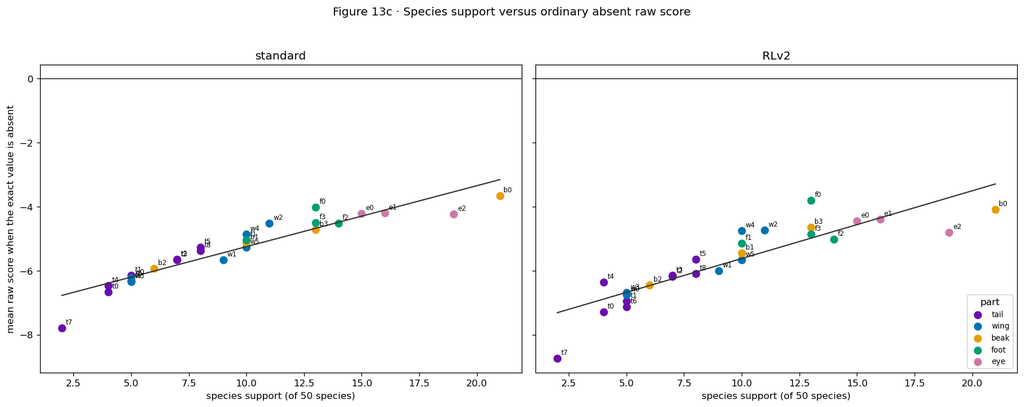

|  | regime | part | concept | value | species_support | N_absent | absent_mean | absent_SD |
| --- | --- | --- | --- | --- | --- | --- | --- | --- |
| 0 | standard | beak | beak_0 | 0 | 21 | 290 | -3.652 | 0.831 |
| 1 | standard | beak | beak_1 | 1 | 10 | 400 | -5.119 | 1.026 |
| 2 | standard | beak | beak_2 | 2 | 6 | 440 | -5.939 | 1.201 |
| 3 | standard | beak | beak_3 | 3 | 13 | 370 | -4.720 | 0.993 |
| 4 | standard | eye | eye_0 | 0 | 15 | 350 | -4.209 | 1.061 |
| 5 | standard | eye | eye_1 | 1 | 16 | 340 | -4.189 | 0.826 |
| 6 | standard | eye | eye_2 | 2 | 19 | 310 | -4.239 | 1.056 |
| 7 | standard | foot | foot_0 | 0 | 13 | 370 | -4.025 | 0.884 |
| 8 | standard | foot | foot_1 | 1 | 10 | 400 | -5.043 | 0.844 |
| 9 | standard | foot | foot_2 | 2 | 14 | 360 | -4.513 | 0.861 |
| 10 | standard | foot | foot_3 | 3 | 13 | 370 | -4.500 | 0.875 |
| 11 | standard | tail | tail_0 | 0 | 4 | 460 | -6.666 | 1.206 |
| 12 | standard | tail | tail_1 | 1 | 5 | 450 | -6.145 | 1.455 |
| 13 | standard | tail | tail_2 | 2 | 7 | 430 | -5.650 | 1.340 |
| 14 | standard | tail | tail_3 | 3 | 7 | 430 | -5.656 | 1.329 |
| 15 | standard | tail | tail_4 | 4 | 4 | 460 | -6.460 | 1.370 |
| 16 | standard | tail | tail_5 | 5 | 8 | 420 | -5.275 | 1.391 |
| 17 | standard | tail | tail_6 | 6 | 5 | 450 | -6.328 | 1.219 |
| 18 | standard | tail | tail_7 | 7 | 2 | 480 | -7.784 | 1.439 |
| 19 | standard | tail | tail_8 | 8 | 8 | 420 | -5.378 | 1.182 |
| 20 | standard | wing | wing_0 | 0 | 5 | 450 | -6.216 | 0.975 |
| 21 | standard | wing | wing_1 | 1 | 9 | 410 | -5.657 | 0.906 |
| 22 | standard | wing | wing_2 | 2 | 11 | 390 | -4.516 | 0.772 |
| 23 | standard | wing | wing_3 | 3 | 5 | 450 | -6.348 | 1.082 |
| 24 | standard | wing | wing_4 | 4 | 10 | 400 | -4.854 | 0.936 |
| 25 | standard | wing | wing_5 | 5 | 10 | 400 | -5.269 | 0.787 |
| 26 | RLv2 | beak | beak_0 | 0 | 21 | 294 | -4.089 | 1.063 |
| 27 | RLv2 | beak | beak_1 | 1 | 10 | 400 | -5.456 | 1.065 |
| 28 | RLv2 | beak | beak_2 | 2 | 6 | 440 | -6.446 | 1.257 |
| 29 | RLv2 | beak | beak_3 | 3 | 13 | 371 | -4.650 | 1.152 |
| 30 | RLv2 | eye | eye_0 | 0 | 15 | 352 | -4.450 | 1.241 |
| 31 | RLv2 | eye | eye_1 | 1 | 16 | 342 | -4.385 | 1.141 |
| 32 | RLv2 | eye | eye_2 | 2 | 19 | 312 | -4.797 | 1.224 |
| 33 | RLv2 | foot | foot_0 | 0 | 13 | 370 | -3.798 | 0.950 |
| 34 | RLv2 | foot | foot_1 | 1 | 10 | 400 | -5.149 | 0.830 |
| 35 | RLv2 | foot | foot_2 | 2 | 14 | 360 | -5.020 | 0.893 |
| 36 | RLv2 | foot | foot_3 | 3 | 13 | 371 | -4.853 | 0.946 |
| 37 | RLv2 | tail | tail_0 | 0 | 4 | 469 | -7.297 | 1.349 |
| 38 | RLv2 | tail | tail_1 | 1 | 5 | 466 | -6.946 | 1.536 |
| 39 | RLv2 | tail | tail_2 | 2 | 7 | 439 | -6.187 | 1.488 |
| 40 | RLv2 | tail | tail_3 | 3 | 7 | 441 | -6.138 | 1.571 |
| 41 | RLv2 | tail | tail_4 | 4 | 4 | 478 | -6.358 | 1.460 |
| 42 | RLv2 | tail | tail_5 | 5 | 8 | 426 | -5.638 | 1.628 |
| 43 | RLv2 | tail | tail_6 | 6 | 5 | 457 | -7.122 | 1.432 |
| 44 | RLv2 | tail | tail_7 | 7 | 2 | 490 | -8.742 | 1.410 |
| 45 | RLv2 | tail | tail_8 | 8 | 8 | 428 | -6.097 | 1.300 |
| 46 | RLv2 | wing | wing_0 | 0 | 5 | 450 | -6.754 | 1.024 |
| 47 | RLv2 | wing | wing_1 | 1 | 9 | 410 | -5.996 | 0.949 |
| 48 | RLv2 | wing | wing_2 | 2 | 11 | 390 | -4.737 | 0.799 |
| 49 | RLv2 | wing | wing_3 | 3 | 5 | 450 | -6.682 | 1.133 |
| 50 | RLv2 | wing | wing_4 | 4 | 10 | 401 | -4.745 | 1.113 |
| 51 | RLv2 | wing | wing_5 | 5 | 10 | 400 | -5.670 | 0.813 |

```python
# ALT: Matched Standard and RLv2 support-versus-absent-score panels with identical axes and exact-value labels.
support_lookup=(SUPPORT_OUTCOMES.query("regime=='standard'")
                .set_index(["part","var_donor"]).species_support)
ABSENT=[]
for regime in ["standard","RLv2"]:
    z=PRED_DATA[regime]["z"];c=PRED_DATA[regime]["c"]
    for j,name in enumerate(CONCEPT_NAMES):
        part=CONCEPT_PART[name];value=j-SPANS[part][0];values=z[c[:,j].astype(int)==0,j]
        ABSENT.append({"regime":regime,"part":part,"concept":name,"value":value,
                       "species_support":int(support_lookup.loc[(part,value)]),
                       "N_absent":len(values),"absent_mean":values.mean(),"absent_SD":values.std(ddof=1)})
ABSENT=pd.DataFrame(ABSENT);fig,axes=plt.subplots(1,2,figsize=(15,6),sharex=True,sharey=True)
for axis,regime in zip(axes,["standard","RLv2"]):
    d0=ABSENT.query("regime==@regime")
    for part in ORDER:
        d=d0.query("part==@part");axis.scatter(d.species_support,d.absent_mean,s=55,color=COLORS[part],label=part)
        for r in d.itertuples():axis.annotate(f"{part[0]}{r.value}",(r.species_support,r.absent_mean),xytext=(4,4),textcoords="offset points",fontsize=7)
    slope,intercept=np.polyfit(d0.species_support,d0.absent_mean,1);grid=np.linspace(d0.species_support.min(),d0.species_support.max(),100)
    axis.plot(grid,intercept+slope*grid,color="#333333",lw=1.3);axis.axhline(0,color="black",lw=.8)
    axis.set_title(regime);axis.set_xlabel("species support (of 50 species)")
axes[0].set_ylabel("mean raw score when the exact value is absent");axes[1].legend(title="part",fontsize=8)
fig.suptitle("Figure 13c · Species support versus ordinary absent raw score")
plt.tight_layout(rect=[0,0,1,.95]);plt.show();display(ABSENT.round(3))
```

### Review record for Figure 13c

- **Literal observation:** The complete executed table immediately above is the authoritative per-part/per-value result. Values are deliberately not hard-coded into the builder before the accepted converged Koh artifacts are executed.
- **Strongest alternative explanation:** Raw-logit scale can change between separately trained models without changing thresholded concept decisions.
- **Discriminating test:** Read this calibration diagnostic beside exact-value recognition, final margins, and the direct saved-head erasure rather than alone.
- **Limited conclusion:** The absent-score baseline describes model calibration for each exact value; it is not itself a backwash rate.
- **Next question:** Did the extra species information and its use by each model's own saved head change?

## 13d · Did RLv2 change species information beyond labels or saved-head magnitude use?

**Question.** Did RLv2 change species information beyond labels or saved-head magnitude use?

**Variables and prediction.** Panels A/B measure held-out species information available after binary labels are known. Panels C/D keep each model's own saved `Wz+b` head fixed and replace raw magnitudes by training-fold means for the same 0/1 label. Backwash can fall without erasing decodable species information. The important comparison is therefore both information available and actual sensitivity of the saved head.

**Method.** Execute the same five-fold functions for each regime. Only the accepted model root, its ordinary raw scores/labels, and its matched swap CSV differ.

**Numerical record.** The code cell prints the complete table used to draw the figure, including the per-part or per-value denominator. The picture is a visual summary of that table, not a separate calculation. Standard and RLv2 always use the same row identities, part order, definitions, bins, and axes unless the section explicitly says otherwise.

### Figure 13d · Did RLv2 change species information beyond labels or saved-head magnitude use?

**How to read the figure.** Because the four-panel construction is already dense, show the complete Standard output first and the complete RLv2 output immediately below rather than redesigning it.

```
STANDARD — identical four-panel calculation
```

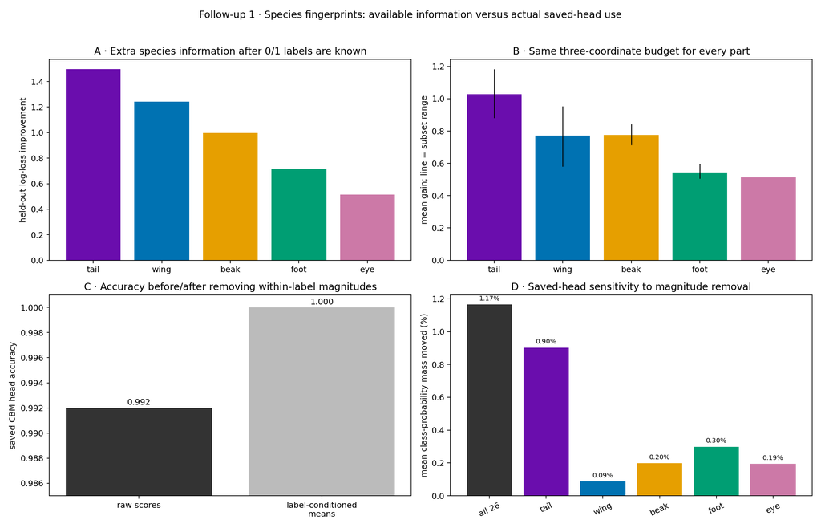

|  | part | coordinates | conditional_logloss_gain | gain_per_coordinate_descriptive |
| --- | --- | --- | --- | --- |
| 0 | beak | 4 | 0.9981 | 0.2495 |
| 1 | eye | 3 | 0.5145 | 0.1715 |
| 2 | foot | 4 | 0.7134 | 0.1784 |
| 3 | tail | 9 | 1.4977 | 0.1664 |
| 4 | wing | 6 | 1.2424 | 0.2071 |

|  | part | three_coordinate_subsets | mean_conditional_gain | min_conditional_gain | max_conditional_gain |
| --- | --- | --- | --- | --- | --- |
| 0 | beak | 4 | 0.7751 | 0.7129 | 0.8426 |
| 1 | eye | 1 | 0.5145 | 0.5145 | 0.5145 |
| 2 | foot | 4 | 0.5448 | 0.5064 | 0.5973 |
| 3 | tail | 40 | 1.0279 | 0.8812 | 1.1840 |
| 4 | wing | 20 | 0.7710 | 0.5812 | 0.9544 |

|  | replaced_block | coordinates_replaced | raw_accuracy | accuracy_after_replacement | top1_change_rate | mean_probability_mass_moved |
| --- | --- | --- | --- | --- | --- | --- |
| 0 | all 26 | 26 | 0.992 | 1.000 | 0.008 | 0.0117 |
| 1 | beak | 4 | 0.992 | 0.992 | 0.000 | 0.0020 |
| 2 | eye | 3 | 0.992 | 0.992 | 0.000 | 0.0019 |
| 3 | foot | 4 | 0.992 | 0.994 | 0.002 | 0.0030 |
| 4 | tail | 9 | 0.992 | 0.998 | 0.006 | 0.0090 |
| 5 | wing | 6 | 0.992 | 0.992 | 0.000 | 0.0009 |

```
RLV2 — identical four-panel calculation
```

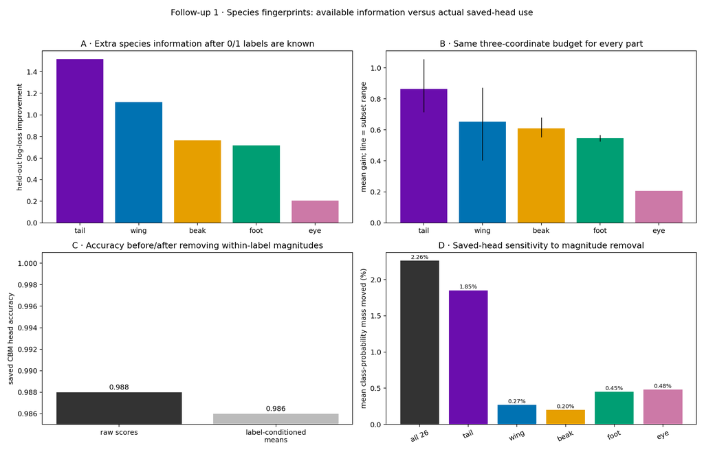

|  | part | coordinates | conditional_logloss_gain | gain_per_coordinate_descriptive |
| --- | --- | --- | --- | --- |
| 0 | beak | 4 | 0.7652 | 0.1913 |
| 1 | eye | 3 | 0.2069 | 0.0690 |
| 2 | foot | 4 | 0.7187 | 0.1797 |
| 3 | tail | 9 | 1.5174 | 0.1686 |
| 4 | wing | 6 | 1.1184 | 0.1864 |

|  | part | three_coordinate_subsets | mean_conditional_gain | min_conditional_gain | max_conditional_gain |
| --- | --- | --- | --- | --- | --- |
| 0 | beak | 4 | 0.6096 | 0.5514 | 0.6805 |
| 1 | eye | 1 | 0.2069 | 0.2069 | 0.2069 |
| 2 | foot | 4 | 0.5461 | 0.5248 | 0.5670 |
| 3 | tail | 40 | 0.8641 | 0.7142 | 1.0564 |
| 4 | wing | 20 | 0.6524 | 0.4034 | 0.8721 |

|  | replaced_block | coordinates_replaced | raw_accuracy | accuracy_after_replacement | top1_change_rate | mean_probability_mass_moved |
| --- | --- | --- | --- | --- | --- | --- |
| 0 | all 26 | 26 | 0.988 | 0.986 | 0.024 | 0.0226 |
| 1 | beak | 4 | 0.988 | 0.986 | 0.004 | 0.0020 |
| 2 | eye | 3 | 0.988 | 0.990 | 0.004 | 0.0048 |
| 3 | foot | 4 | 0.988 | 0.990 | 0.002 | 0.0045 |
| 4 | tail | 9 | 0.988 | 0.982 | 0.020 | 0.0185 |
| 5 | wing | 6 | 0.988 | 0.990 | 0.002 | 0.0027 |

```python
# ALT: Separate Standard and RLv2 four-panel species-information and saved-head-use figures produced by the exact same analysis program.
for regime in ["standard","rlv2"]:
    print(f"{regime.upper()} — identical four-panel calculation")
    display(NotebookImage(filename=str(MATCHED_FOLLOWUP_ROOT/regime/"followup1_information_and_use.png")))
    display(pd.read_csv(MATCHED_FOLLOWUP_ROOT/regime/"followup1_information.csv").round(4))
    display(pd.read_csv(MATCHED_FOLLOWUP_ROOT/regime/"followup1_three_coordinate_sensitivity.csv").round(4))
    display(pd.read_csv(MATCHED_FOLLOWUP_ROOT/regime/"followup1_saved_head_use.csv").round(4))
```

### Review record for Figure 13d

- **Literal observation:** The complete executed table immediately above is the authoritative per-part/per-value result. Values are deliberately not hard-coded into the builder before the accepted converged Koh artifacts are executed.
- **Strongest alternative explanation:** A newly fitted species probe measures information that is available, whereas the frozen CBM head may ignore most of it.
- **Discriminating test:** Panels C/D test each model's own unchanged saved head; Figure 13e then performs the stronger post-swap off-target erasure.
- **Limited conclusion:** Keep information availability separate from actual saved-head use. Neither quantity alone is the controlled concept-backwash endpoint.
- **Next question:** After a swap, does erasing only off-target same-part scores change each saved head's source preference?

## 13e · Did RLv2 change actual saved-head use of the post-swap off-target fingerprint?

**Question.** Did RLv2 change actual saved-head use of the post-swap off-target fingerprint?

**Variables and prediction.** For a tail_2 to tail_7 swap, keep tail_2 and tail_7 unchanged. Replace only the other seven tail scores by their ordinary absent means, rerun the same saved species head, and measure the source-minus-donor class-logit and pairwise-probability change. If RLv2 specifically reduces downstream use of the tail fingerprint, its tail evidence and frozen-head consequence should be smaller than Standard under the identical erasure.

**Method.** Replay all accepted counterfactual images through each accepted checkpoint on CUDA, verify the replayed old/donor coordinates against the saved CSV, and perform only the read-only score replacement described above.

**Numerical record.** The code cell prints the complete table used to draw the figure, including the per-part or per-value denominator. The picture is a visual summary of that table, not a separate calculation. Standard and RLv2 always use the same row identities, part order, definitions, bins, and axes unless the section explicitly says otherwise.

### Figure 13e · Did RLv2 change actual saved-head use of the post-swap off-target fingerprint?

**How to read the figure.** The construction is too dense for an extra color series. Show the Standard three-panel output first and the RLv2 output directly below it.

```
STANDARD — identical off-target erasure
```

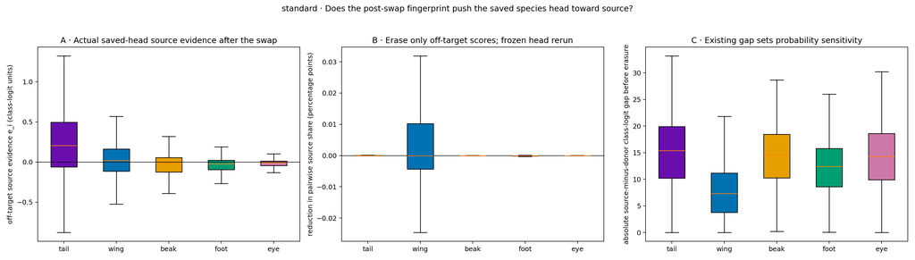

|  | part | n_swaps | n_original_images | off_target_coordinates | mean_e | median_e | fraction_e_positive | median_absolute_e | median_absolute_source_minus_donor_gap | mean_pairwise_source_share_reduction | top1_change_rate | source_to_donor_pair_flip_rate |
| --- | --- | --- | --- | --- | --- | --- | --- | --- | --- | --- | --- | --- |
| 0 | tail | 1000 | 250 | 7 | 0.2261 | 0.2042 | 0.699 | 0.3180 | 15.3748 | 0.0003 | 0.099 | 0.002 |
| 1 | wing | 1000 | 250 | 4 | 0.0212 | 0.0187 | 0.534 | 0.1428 | 7.3557 | 0.0002 | 0.034 | 0.004 |
| 2 | beak | 1000 | 250 | 2 | -0.0325 | -0.0143 | 0.438 | 0.0854 | 14.5976 | -0.0007 | 0.027 | 0.000 |
| 3 | foot | 1000 | 250 | 2 | -0.0406 | -0.0259 | 0.369 | 0.0566 | 12.4407 | -0.0002 | 0.021 | 0.001 |
| 4 | eye | 1000 | 250 | 1 | -0.0198 | -0.0067 | 0.411 | 0.0306 | 14.2733 | -0.0002 | 0.007 | 0.000 |

```
RLV2 — identical off-target erasure
```

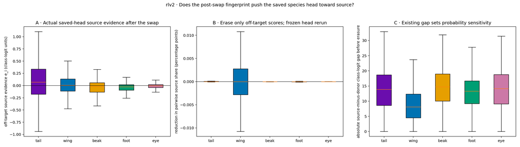

|  | part | n_swaps | n_original_images | off_target_coordinates | mean_e | median_e | fraction_e_positive | median_absolute_e | median_absolute_source_minus_donor_gap | mean_pairwise_source_share_reduction | top1_change_rate | source_to_donor_pair_flip_rate |
| --- | --- | --- | --- | --- | --- | --- | --- | --- | --- | --- | --- | --- |
| 0 | tail | 1000 | 250 | 7 | 0.0982 | 0.0692 | 0.570 | 0.2531 | 13.8831 | 0.0005 | 0.065 | 0.004 |
| 1 | wing | 1000 | 250 | 4 | 0.0111 | 0.0050 | 0.513 | 0.1239 | 8.0957 | 0.0005 | 0.032 | 0.001 |
| 2 | beak | 1000 | 250 | 2 | -0.0343 | -0.0188 | 0.429 | 0.0889 | 14.7241 | -0.0003 | 0.025 | 0.000 |
| 3 | foot | 1000 | 250 | 2 | -0.0383 | -0.0241 | 0.375 | 0.0578 | 13.2839 | -0.0002 | 0.021 | 0.000 |
| 4 | eye | 1000 | 250 | 1 | -0.0151 | -0.0049 | 0.434 | 0.0311 | 14.1149 | -0.0001 | 0.004 | 0.000 |

```python
# ALT: Separate Standard and RLv2 direct off-target-erasure figures produced by the same frozen-head replay analysis.
for regime in ["standard","rlv2"]:
    print(f"{regime.upper()} — identical off-target erasure")
    display(NotebookImage(filename=str(MATCHED_FOLLOWUP_ROOT/regime/"followup2b_direct_erasure.png")))
    display(pd.read_csv(MATCHED_FOLLOWUP_ROOT/regime/"followup2b_direct_erasure_summary.csv").round(4))
```

### Review record for Figure 13e

- **Literal observation:** The complete executed table immediately above is the authoritative per-part/per-value result. Values are deliberately not hard-coded into the builder before the accepted converged Koh artifacts are executed.
- **Strongest alternative explanation:** Changing downstream species logits cannot establish that the species head caused the upstream concept-score error.
- **Discriminating test:** Compare Standard and RLv2 under identical replay while holding the old and inserted concept coordinates fixed.
- **Limited conclusion:** ACCEPTED only for how much the post-swap off-target fingerprint affects the frozen downstream source-versus-donor decision. It does not prove a cause of the upstream concept margin.
- **Next question:** Which measured contributor families improve held-out prediction in each regime?

## 14 · What measured structure predicts each regime's margin on held-out renders?

**Question.** What measured structure predicts each regime's margin on held-out renders?

**Variables and prediction.** For Standard and RLv2 separately, predict final margin and the 0/1 controlled event from the same measured families: part, starting margin, visibility, support, label conflict, ordinary value recognition, and source species. If one family adds predictive information not supplied by the others, held-out error should rise when that family is removed. These are predictive differences, not causal percentages.

**Method.** Use the exact same source-image-grouped five-fold ridge/logistic analysis for each regime. Every swap from one original image stays in one fold.

**Numerical record.** The code cell prints the complete table used to draw the figure, including the per-part or per-value denominator. The picture is a visual summary of that table, not a separate calculation. Standard and RLv2 always use the same row identities, part order, definitions, bins, and axes unless the section explicitly says otherwise.